# [프로젝트] 법률 문서 기반 검색 에이전트

### 4-2. 질문 라우팅

- 사용자의 질문을 분석하여 적절한 에이전트를 선택 (Adaptive RAG 적용)

```python
from typing import Annotated
from operator import add

# 딕셔너리 병합을 위한 사용자 정의 리듀서
def merge_agent_responses(left: dict, right: dict) -> dict:
    """에이전트 응답들을 병합하는 리듀서

    여러 에이전트가 병렬로 실행될 때, 각 에이전트의 응답을
    하나의 딕셔너리로 병합합니다.

    Args:
        left: 기존 응답 딕셔너리
        right: 새로운 응답 딕셔너리

    Returns:
        병합된 응답 딕셔너리
    """
    if left is None:
        left = {}
    if right is None:
        right = {}

    # 딕셔너리 병합
    merged = left.copy()
    merged.update(right)
    return merged

# 상태 정의
class ResearchAgentState(TypedDict):
    """질문 라우팅 및 다중 에이전트 조합 시스템의 상태 정의

    Adaptive RAG 패턴을 적용하여 질문을 분석하고
    적절한 법률 에이전트들을 선택하여 병렬 실행합니다.

    Attributes:
        question: 사용자의 원본 질문
        answers: 각 에이전트가 생성한 답변 리스트 (add 리듀서로 자동 병합)
        agent_responses: 에이전트별 상세 응답 (사용자 정의 리듀서로 병합)
        final_answer: 모든 에이전트 응답을 종합한 최종 답변
        datasources: 선택된 데이터 소스 목록 (법률명 또는 웹)
        evaluation_report: 답변 평가 에이전트의 평가 보고서
        iteration_count: 답변 재생성 횟수 (무한 루프 방지용)
        user_decision: HITL에서 사용자의 계속/종료 결정
        user_feedback: 사용자가 제공하는 피드백
    """
    question: str
    answers: Annotated[List[str], add]  # 각 에이전트의 답변들
    agent_responses: Annotated[dict, merge_agent_responses]  # 병렬 처리 지원 리듀서
    final_answer: str
    datasources: List[str]
    evaluation_report: Optional[dict]
    iteration_count: Optional[int]
    user_decision: Literal["continue", "stop"]  # 사용자 결정 (계속/종료)
    user_feedback: Optional[str]  # 사용자 피드백
```

```python
from typing import Literal
from langchain_core.prompts import ChatPromptTemplate, MessagesPlaceholder
from langchain_core.output_parsers import StrOutputParser
from pydantic import BaseModel, Field

# 라우팅 모델 정의
class ToolSelector(BaseModel):
    """Routes the user question to the most appropriate tool."""
    tool: Literal["search_personal", "search_labor", "search_housing", "search_web", "llm_fallback"] = Field(
        description="Select one of the tools, based on the user's question.",
    )

class ToolSelectors(BaseModel):
    """Select the appropriate tools that are suitable for the user question."""
    tools: List[ToolSelector] = Field(
        description="Select one or more tools, based on the user's question.",
    )

# 라우팅 시스템
structured_llm_tool_selector = llm.with_structured_output(ToolSelectors)

# 라우팅 시스템 프롬프트
system = dedent("""You are an AI assistant specializing in routing user questions to the appropriate tools.
Use the following guidelines to select the most suitable tool(s):

## 법률 관련 도구 (Law-specific Tools)
- **search_personal**: 개인정보 보호법의 구체적인 조항, 법적 규정, 의무사항, 처벌 규정 등에 대한 질문
- **search_labor**: 근로기준법의 구체적인 조항, 근로 조건, 임금, 휴가, 해고 등 법적 규정에 대한 질문
- **search_housing**: 주택임대차보호법의 구체적인 조항, 임대차 계약, 보증금, 임차인 권리 등에 대한 질문

## 웹 검색 도구 (Web Search Tool)
**search_web**을 사용하는 경우:
- 최신 정보나 실시간 데이터가 필요한 질문
- 현재 뉴스, 트렌드, 최근 사건에 대한 질문
- 법률 관련이지만 구체적인 조항보다는 현실적 적용 사례나 판례가 필요한 경우
- 통계, 시장 데이터, 가격 정보 등 변동하는 정보
- 특정 회사, 제품, 서비스에 대한 현재 정보

## LLM 일반 응답 도구 (LLM Fallback Tool)
**llm_fallback**을 사용하는 경우:
- **개념적/이론적 설명**: 일반적인 개념, 정의, 원리 설명 (검색 불필요)
- **창의적 작업**: 글쓰기, 시, 소설, 아이디어 생성 등
- **논리적 추론**: 수학 계산, 논리 문제, 분석적 사고
- **개인적 조언**: 의견, 추천, 개인적 상담 (사실 확인 불필요)
- **일반적 대화**: 인사, 감사, 일상 대화
- **질문이 모호하거나 분류하기 어려운 경우**

Always choose all of the appropriate tools based on the user's question.
If a question is about a law but doesn't seem to be asking about specific legal provisions, include both the relevant law search tool and the search_web tool.
""")

route_prompt = ChatPromptTemplate.from_messages([
    ("system", system),
    MessagesPlaceholder("user_feedback"),
    ("human", "{question}"),
])

question_tool_router = route_prompt | structured_llm_tool_selector

# 테스트 실행
print(question_tool_router.invoke({"question": "근로계약 체결할 때 개인정보 취급 상의 유의사항은 무엇인가요?", "user_feedback": []}))
print(question_tool_router.invoke({"question": "개인정보보호법에서 정한 가명정보의 정의는 무엇인가요?", "user_feedback": []}))
print(question_tool_router.invoke({"question": "대리인과 아파트 임대차 계약을 체결할 때 주의해야 할 점은 무엇인가요?", "user_feedback": []}))
print(question_tool_router.invoke({"question": "오늘 날씨 어때?", "user_feedback": []}))
print(question_tool_router.invoke({"question": "내 이름은 무엇인가요?", "user_feedback": []}))
```

```
tools=[ToolSelector(tool='search_labor'), ToolSelector(tool='search_personal')]
tools=[ToolSelector(tool='search_personal')]
tools=[ToolSelector(tool='search_housing')]
tools=[ToolSelector(tool='search_web')]
tools=[ToolSelector(tool='llm_fallback')]
```

```python
def analyze_question_tool_search(state: ResearchAgentState):
    """질문을 분석하여 적절한 도구들을 선택"""
    question = state["question"]
    print(f"도구 선택을 위해 질문 분석 중: {question}")

    # 사용자 피드백이 있는 경우, 도구 선택에 반영
    user_feedback = state.get("user_feedback", None)

    result = question_tool_router.invoke({
        "question": question,
        "user_feedback": [("system", f"***You SHOULD consider the following user feedback when selecting tools:***\n<User feedback>{user_feedback}</User feedback>")] if user_feedback else []
    })

    datasources = [tool.tool for tool in result.tools]
    print(f"선택된 도구들: {datasources}")
    return {"datasources": datasources, "agent_responses": {}}

def route_datasources_tool_search(state: ResearchAgentState) -> List[str]:
    """선택된 데이터 소스들로 라우팅"""
    datasources = set(state['datasources'])
    valid_sources = {"search_personal", "search_labor", "search_housing", "search_web", "llm_fallback"}

    if datasources.issubset(valid_sources):
        return list(datasources)

    return ["llm_fallback"]  # 유효한 도구 호출이 없는 경우, 기본적으로 LLM 폴백 사용
```

```python
# 최종 답변 생성 프롬프트
rag_prompt = ChatPromptTemplate.from_messages([
    ("system", """You are an expert assistant specializing in synthesizing and integrating multiple agent responses to provide comprehensive, accurate answers.

## Core Guidelines

### 1. Information Integration Strategy
- **Synthesize ALL available information** from different agents to create the most complete answer
- **Prioritize accuracy and relevance** over brevity
- **Combine complementary information** from multiple sources to enhance answer quality
- **Preserve the unique value** each agent contributes

### 2. Source Prioritization (in order of reliability)
1. **Legal provisions** (개인정보보호법, 근로기준법, 주택임대차보호법 agents)
2. **Official government sources** (from web search)
3. **Authoritative websites and institutions**
4. **Recent news and reliable media**
5. **General web sources**

### 3. Content Integration Rules
- **Start with the most authoritative answer** as the foundation
- **Add supplementary information** from other agents to enrich the response
- **Include practical applications** and real-world context when available
- **Mention recent developments** or updates if provided by web search
- **Address different aspects** of the question using information from multiple agents

### 4. Citation Format (Enhanced)
- **Legal provisions**: "법률명 제X조 Y항"
- **Web sources**: "출처명 (URL, 날짜)"
- **Multiple agents**: "복수 출처 종합"
- **Comparative info**: "A에 따르면 X이며 (출처A), B는 Y로 보완 설명함 (출처B)"

### 5. Answer Structure Template
1. **핵심 답변**: 질문에 대한 직접적이고 명확한 답변
2. **법적 근거**: 관련 법률 조항 및 규정 (해당 시)
3. **실무적 적용**: 현실적인 적용 방법이나 절차
4. **최신 동향**: 최근 변화나 업데이트 사항 (해당 시)
5. **주의사항**: 예외 조건이나 추가 고려사항

### 6. Special Instructions
- **Never discard valuable information** from any agent unless it's clearly incorrect
- **Always attempt to find connections** between different pieces of information
- **Include quantitative data** (dates, amounts, percentages) when available

Only say "제공된 정보로는 충분한 답변을 할 수 없습니다" if NO agents provided relevant information.
"""
    ),
    MessagesPlaceholder("user_feedback"),
    ("human", """Synthesize the following agent responses to provide a comprehensive answer to the user's question.

<Question>
{question}
</Question>

<Agent Responses>
{agent_responses}
</Agent Responses>

Create a comprehensive, well-structured answer that maximizes the value of all provided information."""),
])

# 에이전트 응답 포맷터
def format_agent_responses(agent_responses_dict):
    """에이전트 응답들을 프롬프트에 적합한 형태로 포맷팅"""
    if not agent_responses_dict:
        return "에이전트 응답이 없습니다."

    formatted_responses = []
    agent_labels = {
        'search_personal': '🔒 개인정보보호법 전문 에이전트',
        'search_labor': '⚖️ 근로기준법 전문 에이전트',
        'search_housing': '🏠 주택임대차보호법 전문 에이전트',
        'search_web': '🌐 웹 검색 에이전트',
        'llm_fallback': '🤖 일반 지식 에이전트'
    }

    for agent_type, response in agent_responses_dict.items():
        if response and response.strip():
            label = agent_labels.get(agent_type, f'📋 {agent_type} 에이전트')
            formatted_responses.append(f"{label}:\n{response.strip()}\n")

    return "\n" + "="*50 + "\n".join(formatted_responses) + "="*50
```

```python
def personal_rag_node(state: ResearchAgentState) -> ResearchAgentState:
    """개인정보보호법 전문 에이전트"""
    print("--- 개인정보보호법 전문가 에이전트 시작 ---")
    question = state["question"]
    user_feedback = state.get("user_feedback", None)

    answer = personal_law_agent.invoke({
        "question": question,
        "user_feedback": [("system", f"답변을 생성할 때 다음 사용자 피드백을 고려하세요:\n<피드백>{user_feedback}</피드백>")] if user_feedback else []
    })
    response_text = answer.get("node_answer", "답변을 생성할 수 없습니다.")

    # 에이전트별 응답 저장
    current_responses = state.get("agent_responses", {}).copy()
    current_responses["search_personal"] = response_text

    return {
        "answers": [response_text],
        "agent_responses": current_responses
    }

def labor_rag_node(state: ResearchAgentState) -> ResearchAgentState:
    """근로기준법 전문 에이전트"""
    print("--- 근로기준법 전문가 에이전트 시작 ---")
    question = state["question"]
    user_feedback = state.get("user_feedback", None)

    answer = labor_law_agent.invoke({
        "question": question,
        "user_feedback": [("system", f"답변을 생성할 때 다음 사용자 피드백을 고려하세요:\n<피드백>{user_feedback}</피드백>")] if user_feedback else []
    })
    response_text = answer.get("node_answer", "답변을 생성할 수 없습니다.")
    current_responses = state.get("agent_responses", {}).copy()
    current_responses["search_labor"] = response_text

    return {
        "answers": [response_text],
        "agent_responses": current_responses
    }

def housing_rag_node(state: ResearchAgentState) -> ResearchAgentState:
    """주택임대차보호법 전문 에이전트"""
    print("--- 주택임대차보호법 전문가 에이전트 시작 ---")
    question = state["question"]
    user_feedback = state.get("user_feedback", None)

    answer = housing_law_agent.invoke({
        "question": question,
        "user_feedback": [("user", f"답변을 생성할 때 다음 사용자 피드백을 고려하세요:\n<피드백>{user_feedback}</피드백>")] if user_feedback else []
    })
    response_text = answer.get("node_answer", "답변을 생성할 수 없습니다.")

    current_responses = state.get("agent_responses", {}).copy()
    current_responses["search_housing"] = response_text

    return {
        "answers": [response_text],
        "agent_responses": current_responses
    }



def web_rag_node(state: ResearchAgentState) -> ResearchAgentState:
    """웹 검색 전문 에이전트"""
    print("--- 인터넷 검색 전문가 에이전트 시작 ---")
    question = state["question"]
    user_feedback = state.get("user_feedback", None)

    answer = search_web_agent.invoke({
        "question": question,
        "user_feedback": [("user", f"답변을 생성할 때 다음 사용자 피드백을 고려하세요:\n<피드백>{user_feedback}</피드백>")] if user_feedback else []
    })
    response_text = answer.get("node_answer", "답변을 생성할 수 없습니다.")

    current_responses = state.get("agent_responses", {}).copy()
    current_responses["search_web"] = response_text

    return {
        "answers": [response_text],
        "agent_responses": current_responses
    }

def answer_final(state: ResearchAgentState) -> dict:
    """최종 답변 생성 함수"""
    print("---최종 답변 생성---")
    question = state["question"]
    user_feedback = state.get("user_feedback", None)
    # 에이전트 응답들을 가져옴
    agent_responses = state.get("agent_responses", {})

    # 에이전트 응답이 있는지 확인
    if not agent_responses:
        return {
            "final_answer": "에이전트로부터 답변을 받지 못했습니다.",
            "question": question
        }

    # 에이전트 응답 포맷팅
    formatted_responses = format_agent_responses(agent_responses)

    print(f"통합할 에이전트 응답 수: {len(agent_responses)}")
    for agent_type in agent_responses.keys():
        print(f"  - {agent_type}")

    # RAG 체인으로 최종 답변 생성
    rag_chain = rag_prompt | llm | StrOutputParser()

    generation = rag_chain.invoke({
        "question": question,
        "agent_responses": formatted_responses,
        "user_feedback": [("system", f"최종 답변을 생성할 때 다음 사용자 피드백을 고려하세요:\n<피드백>{user_feedback}</피드백>")] if user_feedback else []
    })
    print(f"최종 답변 생성 완료: {generation[:100]}...")  # 처음 100자만 출력

    return {
        "final_answer": generation,
        "question": question
    }

# ===== LLM Fallback =====
fallback_prompt = ChatPromptTemplate.from_messages([
    ("system", """You are an AI assistant helping with various topics. Follow these guidelines:
1. Provide accurate and helpful information to the best of your ability.
2. Express uncertainty when unsure; avoid speculation.
3. Keep answers concise yet informative.
4. Respond ethically and constructively."""),
    MessagesPlaceholder("user_feedback"),
    ("human", "{question}"),
])

def llm_fallback(state: ResearchAgentState) -> dict:
    """LLM 일반 응답"""
    print("---Fallback 답변---")
    question = state["question"]
    user_feedback = state.get("user_feedback", None)

    llm_chain = fallback_prompt | llm | StrOutputParser()
    generation = llm_chain.invoke({
        "question": question,
        "user_feedback": [("system", f"답변을 생성할 때 다음 사용자 피드백을 고려하세요:\n<피드백>{user_feedback}</피드백>")] if user_feedback else []
    })
    print(f"Fallback 답변 생성 완료: {generation[:100]}...")  # 처음 100자만 출력
    return {
        "final_answer": generation,
        "question": question
    }
```

```python
# 노드 정의를 딕셔너리로 관리
nodes = {
    "analyze_question": analyze_question_tool_search,
    "search_personal": personal_rag_node,
    "search_labor": labor_rag_node,
    "search_housing": housing_rag_node,
    "search_web": web_rag_node,
    "generate_answer": answer_final,
    "llm_fallback": llm_fallback
}

# 그래프 생성
search_builder = StateGraph(ResearchAgentState)

# 노드 추가
for node_name, node_func in nodes.items():
    search_builder.add_node(node_name, node_func)

# 엣지 추가
search_builder.add_edge(START, "analyze_question")

# 조건부 엣지 (병렬 처리)
search_builder.add_conditional_edges(
    "analyze_question",
    route_datasources_tool_search,
    ["search_personal", "search_labor", "search_housing", "search_web", "llm_fallback"]
)

# 검색 노드들을 generate_answer에 연결
for node in ["search_personal", "search_labor", "search_housing", "search_web"]:
    search_builder.add_edge(node, "generate_answer")

search_builder.add_edge("generate_answer", END)
search_builder.add_edge("llm_fallback", END)

# 그래프 컴파일
rag_search_graph = search_builder.compile()
```

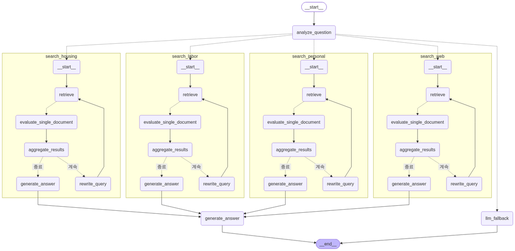

```python
# 그래프 시각화
display(Image(rag_search_graph.get_graph(xray=True).draw_mermaid_png()))
```

```python
# 1개의 도구가 선택된 경우
inputs = {
    "question": "대리인과 아파트 임대차 계약을 체결할 때 주의해야 할 점은 무엇인가요?"
}
for output in rag_search_graph.stream(inputs):
    for key, value in output.items():
        # 노드 출력
        pprint(f"Node '{key}':")
        pprint(f"Value: {value}", indent=2, width=80, depth=None)
    print("\n----------------------------------------------------------\n")
```

````
도구 선택을 위해 질문 분석 중: 대리인과 아파트 임대차 계약을 체결할 때 주의해야 할 점은 무엇인가요?
선택된 도구들: ['search_housing']
"Node 'analyze_question':"
"Value: {'datasources': ['search_housing'], 'agent_responses': {}}"

----------------------------------------------------------

--- 주택임대차보호법 전문가 에이전트 시작 ---
---주택임대차보호법 문서 검색---
---주택임대차보호법 관련 4개 문서에 대한 평가 병렬 워커 생성---
---주택임대차보호법 관련 단일 문서 처리 중 (길이: 437...)---
---주택임대차보호법 관련 단일 문서 처리 중 (길이: 1617...)---
---주택임대차보호법 관련 단일 문서 처리 중 (길이: 243...)---
---주택임대차보호법 관련 단일 문서 처리 중 (길이: 272...)---
문서 관련성이 낮음: 0.75
문서 관련성이 낮음: 0.75
고품질 정보 2개 추출됨
고품질 정보 4개 추출됨
---주택임대차보호법 관련 총 6개의 정보 조각 집계---
EmbeddingsRedundantFilter 중복 제거: 6 → 6개
최종 결과: 6 → 6  → 6개
---주택임대차보호법 답변 생성---
"Node 'search_housing':"
("Value: {'answers': ['```markdown\\n### 1. 질문에 대한 직접적인 답변\\n대리인과 아파트 임대차 계약을 "
 '체결할 때는 임대인의 명확한 동의 여부를 반드시 확인해야 하며, 임대차 계약 조건(확정일자, 차임, 보증금 등)을 임차인에게 정확히 '
 '제시해야 합니다. 또한, 대리인이 임대인의 동의 없이 주택을 전대하는 경우 계약갱신 요구가 거절될 수 있으므로 주의가 필요합니다. '
 '임대인이 실제 거주할 계획이 있는지도 확인하는 것이 중요합니다.\\n\\n### 2. 관련 법률 조항 및 해석\\n- **주택임대차보호법 '
 '제3조의7**  \\n  임대인은 임차인에게 확정일자 부여일, 차임, 보증금 등의 정보를 제공해야 하며, 국세 및 지방세 납세증명서 제시 '
 '또는 미납세 열람 동의도 요구할 수 있습니다.  \\n  (출처: 주택임대차보호법 제3조의7)\\n\\n- **주택임대차보호법 제6조의3 '
 '제1항**  \\n  임대인은 정당한 사유 없이 임차인의 계약갱신 요구를 거절하지 못하나, 대리인이 임대인의 동의 없이 주택 전부 또는 '
 '일부를 전대하는 경우 계약갱신 요구를 거절할 수 있습니다. 또한 임대인이 실제 거주하려는 경우에도 계약갱신 요구를 거절할 수 있습니다.  '
 '\\n  (출처: 주택임대차보호법 제6조의3 제1항 전단 및 4호, 8호)\\n\\n### 3. 추가 설명 또는 예시\\n- **대리인 '
 '동의 확인**  \\n  대리인이 계약을 체결할 때 임대인의 위임장이나 동의서 등 공식적인 증빙을 반드시 확인해야 합니다. 임대인의 동의 '
 '없이 계약을 체결하면 임대차 계약의 안정성이 떨어지고, 추후 계약갱신 문제에서 불이익을 받을 수 있습니다.\\n\\n- **전대 '
 '문제**  \\n  대리인이 임대인의 동의 없이 주택을 전대하는 경우, 임차인은 계약갱신을 요구해도 임대인이 거절할 수 있으므로, 전대 '
 '여부를 명확히 하고 계약서에 이를 명시하는 것이 좋습니다.\\n\\n- **임대인의 거주 계획 확인**  \\n  임대인이 실제로 주택에 '
 '거주할 계획이 있다면 계약갱신 요구가 거절될 수 있으므로, 대리인 계약 시 임대인의 거주 의사를 사전에 확인하는 것이 '
 '중요합니다.\\n\\n### 4. 결론 및 요약\\n대리인과 아파트 임대차 계약을 체결할 때는 임대인의 명확한 동의 확인과 임대차 조건의 '
 '투명한 제시가 필수적입니다. 특히 대리인의 전대 행위 여부와 임대인의 실제 거주 계획을 반드시 확인하여 계약갱신 거절 사유가 발생하지 '
 '않도록 주의해야 합니다. 이를 통해 임대차 계약의 안정성과 임차인의 권리를 보호할 수 있습니다.\\n\\n(출처: 주택임대차보호법 '
````

[output cut: 32 more lines]

```
 '합니다.\\n\\n2. **법적 근거**  \\n- **주택임대차보호법 제3조의7**: 임대인은 임차인에게 확정일자 부여일, 차임, '
 '보증금 등의 정보를 제공해야 하며, 국세 및 지방세 납세증명서 제시 또는 미납세 열람 동의도 요구할 수 있습니다.  \\n- '
 '**주택임대차보호법 제6조의3 제1항**: 임대인은 정당한 사유 없이 임차인의 계약갱신 요구를 거절하지 못하나, 대리인이 임대인의 동의 '
 '없이 주택 전부 또는 일부를 전대하는 경우, 또는 임대인이 실제 거주하려는 경우에는 계약갱신 요구를 거절할 수 있습니다.\\n\\n3. '
 '**실무적 적용**  \\n- **대리인 동의 확인**: 대리인이 계약을 체결할 때는 임대인의 위임장이나 동의서 등 공식적인 증빙서류를 '
 '반드시 확인해야 합니다.  \\n- **계약 조건 명확화**: 계약서에 확정일자, 차임, 보증금, 전대 여부, 임대인의 거주 계획 등을 '
 '명확히 기재하여 분쟁 소지를 줄입니다.  \\n- **임대인의 거주 계획 확인**: 임대인이 실제 거주할 의사가 있는지 사전에 확인하여 '
 '계약갱신 거절 가능성을 미리 파악합니다.\\n\\n4. **주의사항**  \\n- 임대인의 동의 없이 대리인이 계약을 체결하거나 전대하는 '
 '경우, 임차인은 계약갱신에서 불이익을 받을 수 있으므로 각별히 주의해야 합니다.  \\n- 계약서 작성 시 대리인의 권한 범위와 임대인의 '
 '동의 내용을 명확히 기재하는 것이 중요합니다.\\n\\n요약하면, 대리인과 아파트 임대차 계약 체결 시 임대인의 명확한 동의 확인과 계약 '
 '조건의 투명한 제시, 전대 여부 및 임대인의 거주 계획 확인이 필수적이며, 이를 통해 임대차 계약의 안정성과 임차인의 권리를 보호할 수 '
 "있습니다.\\n\\n(출처: 주택임대차보호법 제3조의7, 제6조의3 제1항 종합)', 'question': '대리인과 아파트 임대차 "
 "계약을 체결할 때 주의해야 할 점은 무엇인가요?'}")

----------------------------------------------------------
```

```python
# 마크다운 형식으로 출력
from IPython.display import Markdown
display(Markdown(value['final_answer']))
```

1. **핵심 답변**  
   대리인과 아파트 임대차 계약을 체결할 때는 반드시 임대인의 명확한 동의 여부를 확인해야 하며, 임대차 계약 조건(확정일자, 차임, 보증금 등)을 임차인에게 정확히 제시해야 합니다. 특히 대리인이 임대인의 동의 없이 주택을 전대하는 경우 계약갱신 요구가 거절될 수 있으므로, 전대 여부를 명확히 하고 계약서에 이를 명시하는 것이 중요합니다. 또한 임대인이 실제로 주택에 거주할 계획이 있는지도 사전에 확인하여 계약갱신 거절 사유가 발생하지 않도록 주의해야 합니다.

2. **법적 근거**

- **주택임대차보호법 제3조의7**: 임대인은 임차인에게 확정일자 부여일, 차임, 보증금 등의 정보를 제공해야 하며, 국세 및 지방세 납세증명서 제시 또는 미납세 열람 동의도 요구할 수 있습니다.

- **주택임대차보호법 제6조의3 제1항**: 임대인은 정당한 사유 없이 임차인의 계약갱신 요구를 거절하지 못하나, 대리인이 임대인의 동의 없이 주택 전부 또는 일부를 전대하는 경우, 또는 임대인이 실제 거주하려는 경우에는 계약갱신 요구를 거절할 수 있습니다.

3. **실무적 적용**

- **대리인 동의 확인**: 대리인이 계약을 체결할 때는 임대인의 위임장이나 동의서 등 공식적인 증빙서류를 반드시 확인해야 합니다.

- **계약 조건 명확화**: 계약서에 확정일자, 차임, 보증금, 전대 여부, 임대인의 거주 계획 등을 명확히 기재하여 분쟁 소지를 줄입니다.

- **임대인의 거주 계획 확인**: 임대인이 실제 거주할 의사가 있는지 사전에 확인하여 계약갱신 거절 가능성을 미리 파악합니다.

4. **주의사항**

- 임대인의 동의 없이 대리인이 계약을 체결하거나 전대하는 경우, 임차인은 계약갱신에서 불이익을 받을 수 있으므로 각별히 주의해야 합니다.

- 계약서 작성 시 대리인의 권한 범위와 임대인의 동의 내용을 명확히 기재하는 것이 중요합니다.

요약하면, 대리인과 아파트 임대차 계약 체결 시 임대인의 명확한 동의 확인과 계약 조건의 투명한 제시, 전대 여부 및 임대인의 거주 계획 확인이 필수적이며, 이를 통해 임대차 계약의 안정성과 임차인의 권리를 보호할 수 있습니다.

(출처: 주택임대차보호법 제3조의7, 제6조의3 제1항 종합)

```python
# 2개의 도구가 선택된 경우
inputs = {"question": "근로계약 체결할 때 개인정보 취급 상의 유의사항은 무엇인가요?"}
for output in rag_search_graph.stream(inputs):
    for key, value in output.items():
        # 노드 출력
        pprint(f"Node '{key}':")
        pprint(f"Value: {value}", indent=2, width=80, depth=None)
    print("\n----------------------------------------------------------\n")
```

````
도구 선택을 위해 질문 분석 중: 근로계약 체결할 때 개인정보 취급 상의 유의사항은 무엇인가요?
선택된 도구들: ['search_labor', 'search_personal']
"Node 'analyze_question':"
("Value: {'datasources': ['search_labor', 'search_personal'], "
 "'agent_responses': {}}")

----------------------------------------------------------

--- 근로기준법 전문가 에이전트 시작 ---
---근로기준법 문서 검색---
--- 개인정보보호법 전문가 에이전트 시작 ---
---개인정보보호법 문서 검색---
---근로기준법 관련 4개 문서에 대한 평가 병렬 워커 생성---
---근로기준법 단일 문서 처리 중 (길이: 365...)---
---근로기준법 단일 문서 처리 중 (길이: 205...)---
---근로기준법 단일 문서 처리 중 (길이: 146...)---
---근로기준법 단일 문서 처리 중 (길이: 214...)---
고품질 정보 1개 추출됨
고품질 정보 2개 추출됨
---개인정보보호법 관련 4개 문서에 대한 평가 병렬 워커 생성---
---개인정보보호법 단일 문서 처리 중 (길이: 1094...)---
---개인정보보호법 단일 문서 처리 중 (길이: 1001...)---
---개인정보보호법 단일 문서 처리 중 (길이: 490...)---
---개인정보보호법 단일 문서 처리 중 (길이: 302...)---
문서 관련성이 낮음: 0.6
문서 관련성이 낮음: 0.6
---근로기준법 관련 총 3개의 정보 조각 집계---
문서 관련성이 낮음: 0.4
고품질 정보 3개 추출됨
EmbeddingsRedundantFilter 중복 제거: 3 → 3개
최종 결과: 3 → 3  → 3개
---근로기준법 답변 생성---
고품질 정보 3개 추출됨
고품질 정보 3개 추출됨
---개인정보보호법 관련 총 9개의 정보 조각 집계---
---개인정보보호법 답변 생성---
"Node 'search_labor':"
("Value: {'answers': ['```markdown\\n### 1. 질문에 대한 직접적인 답변\\n근로계약 체결 시 개인정보 "
 '취급에 있어 특히 18세 미만 근로자의 경우, 연령을 증명할 수 있는 가족관계기록사항에 관한 증명서와 친권자 또는 후견인의 동의서를 '
 '반드시 사업장에 비치하고 보관해야 합니다. 또한, 18세 미만 근로자와 계약할 때는 근로조건을 서면 또는 전자문서로 명확히 명시하여 '
````

[output cut: 99 more lines]

```
 '필수적인 개인정보만 수집하고, 건강 상태 등 민감정보는 별도의 동의를 받아야 합니다.  \\n- 개인정보 수집 시 근로자에게 수집 목적, '
 '보유 기간, 동의 거부 권리 등을 서면 또는 전자문서로 명확히 안내하고, 개인정보 처리방침을 회사 홈페이지나 근로자가 쉽게 접근할 수 '
 '있는 곳에 공개합니다.  \\n- 18세 미만 근로자 채용 시 가족관계증명서와 친권자 동의서를 반드시 확보·보관하며, 근로조건을 서면 '
 '또는 전자문서로 명확히 명시하여 근로자에게 교부합니다.  \\n- 개인정보는 안전한 장소에 보관하고, 무단 열람·유출 방지를 위한 내부 '
 '관리체계를 갖춥니다.  \\n- 근로자가 추가 개인정보 제공에 동의하지 않아도 근로계약 체결이나 근로 조건에 불이익을 주지 않도록 '
 '주의합니다.\\n\\n4. **주의사항**  \\n- 개인정보 수집 및 이용 목적과 범위를 명확히 하여 근로자에게 충분히 고지하고 동의를 '
 '받는 것이 중요합니다.  \\n- 18세 미만 근로자의 개인정보는 민감정보로 분류되므로 더욱 엄격한 보안 관리가 필요합니다.  \\n- '
 '개인정보 처리방침과 근로계약서 내용이 상충할 경우 근로자에게 유리한 내용을 적용해야 합니다.  \\n- 개인정보 유출 시 법적 책임과 '
 '신뢰 하락이 발생할 수 있으므로, 관련 법규를 철저히 준수해야 합니다.\\n\\n---\\n\\n**요약**: 근로계약 체결 시 '
 '개인정보는 법적 근거에 따라 최소한으로 수집하고, 수집 목적과 권리를 명확히 고지하며, 18세 미만 근로자의 경우 연령 증명서류와 친권자 '
 '동의서를 반드시 보관해야 합니다. 또한 개인정보 처리방침을 수립·공개하고, 동의하지 않는 경우 불이익을 주지 않아야 하며, 개인정보 '
 '보호를 위한 안전한 관리가 필수적입니다.  \\n(출처: 개인정보 보호법 제15조, 제16조, 제30조 / 근로기준법 제66조, 제67조 '
 "③, 복수 출처 종합)', 'question': '근로계약 체결할 때 개인정보 취급 상의 유의사항은 무엇인가요?'}")

----------------------------------------------------------
```

```python
# 마크다운 형식으로 출력
from IPython.display import Markdown
display(Markdown(value['final_answer']))
```

1. **핵심 답변**  
   근로계약 체결 시 개인정보 취급에 있어서는 다음과 같은 유의사항이 있습니다.

- 개인정보는 근로계약 목적에 필요한 최소한의 범위 내에서만 수집해야 하며, 정보주체(근로자)의 동의를 받거나 법률상 정당한 사유가 있어야 합니다.

- 개인정보 수집 시에는 수집·이용 목적, 수집 항목, 보유 및 이용 기간, 동의 거부 권리 및 불이익 여부를 명확히 고지해야 하며, 개인정보 처리방침을 수립·공개해야 합니다.

- 18세 미만 근로자의 경우, 연령을 증명할 수 있는 가족관계증명서와 친권자 또는 후견인의 동의서를 반드시 사업장에 비치·보관해야 하며, 근로조건을 서면 또는 전자문서로 명확히 명시하여 교부해야 합니다.

- 정보주체가 최소한의 정보 외 개인정보 수집에 동의하지 않는다고 하여 근로계약 체결이나 근로 조건에 불이익을 주어서는 안 됩니다.

2. **법적 근거**

- 개인정보 보호법

  - 제15조(개인정보의 수집·이용) 제1항, 제2항: 개인정보 수집은 동의 또는 법적 근거가 있어야 하며, 수집 목적·항목·보유 기간 등을 고지해야 함

  - 제16조(개인정보의 수집 제한) 제1~3항: 최소한의 개인정보만 수집하고, 동의 거부 시 불이익 금지

  - 제30조: 개인정보 처리방침 수립·공개 의무

- 근로기준법

  - 제66조(연소자 증명서): 18세 미만 근로자의 연령 증명서 및 친권자 동의서 보관 의무

  - 제67조 ③: 18세 미만 근로자와 근로조건을 서면 또는 전자문서로 명확히 교부해야 함

3. **실무적 적용**

- 근로계약서 작성 시 주민등록번호, 연락처, 은행계좌번호 등 계약 이행에 필수적인 개인정보만 수집하고, 건강 상태 등 민감정보는 별도의 동의를 받아야 합니다.

- 개인정보 수집 시 근로자에게 수집 목적, 보유 기간, 동의 거부 권리 등을 서면 또는 전자문서로 명확히 안내하고, 개인정보 처리방침을 회사 홈페이지나 근로자가 쉽게 접근할 수 있는 곳에 공개합니다.

- 18세 미만 근로자 채용 시 가족관계증명서와 친권자 동의서를 반드시 확보·보관하며, 근로조건을 서면 또는 전자문서로 명확히 명시하여 근로자에게 교부합니다.

- 개인정보는 안전한 장소에 보관하고, 무단 열람·유출 방지를 위한 내부 관리체계를 갖춥니다.

- 근로자가 추가 개인정보 제공에 동의하지 않아도 근로계약 체결이나 근로 조건에 불이익을 주지 않도록 주의합니다.

4. **주의사항**

- 개인정보 수집 및 이용 목적과 범위를 명확히 하여 근로자에게 충분히 고지하고 동의를 받는 것이 중요합니다.

- 18세 미만 근로자의 개인정보는 민감정보로 분류되므로 더욱 엄격한 보안 관리가 필요합니다.

- 개인정보 처리방침과 근로계약서 내용이 상충할 경우 근로자에게 유리한 내용을 적용해야 합니다.

- 개인정보 유출 시 법적 책임과 신뢰 하락이 발생할 수 있으므로, 관련 법규를 철저히 준수해야 합니다.

**요약**: 근로계약 체결 시 개인정보는 법적 근거에 따라 최소한으로 수집하고, 수집 목적과 권리를 명확히 고지하며, 18세 미만 근로자의 경우 연령 증명서류와 친권자 동의서를 반드시 보관해야 합니다. 또한 개인정보 처리방침을 수립·공개하고, 동의하지 않는 경우 불이익을 주지 않아야 하며, 개인정보 보호를 위한 안전한 관리가 필수적입니다.  
(출처: 개인정보 보호법 제15조, 제16조, 제30조 / 근로기준법 제66조, 제67조 ③, 복수 출처 종합)

# 5. 답변 평가 및 확인

### 5-1. 답변을 평가하는 ReAct 에이전트

```python
from textwrap import dedent

evaluation_prompt = dedent("""
당신은 AI 어시스턴트가 생성한 답변을 평가하는 전문가입니다. 주어진 질문과 답변을 평가하고, 60점 만점으로 점수를 매기세요. 다음 기준을 사용하여 평가하십시오:

1. 정확성 (10점)
2. 관련성 (10점)
3. 완전성 (10점)
4. 인용 정확성 (10점)
5. 명확성과 간결성 (10점)
6. 객관성 (10점)

평가 과정:
1. 주어진 질문과 답변을 주의 깊게 읽으십시오.
2. 필요한 경우, 다음 도구를 사용하여 추가 정보를 수집하세요:
   - web_search: 웹 검색
   - personal_law_search: 개인정보보호법 검색
   - labor_law_search: 근로기준법 검색
   - housing_law_search: 주택임대차보호법 검색

   도구 사용 형식:
   Action: [tool_name]
   Action Input: [input for the tool]

3. 각 기준에 대해 1-10점 사이의 점수를 매기세요.
4. 총점을 계산하세요 (60점 만점).

출력 형식:
{
  "scores": {
    "accuracy": 0,
    "relevance": 0,
    "completeness": 0,
    "citation_accuracy": 0,
    "clarity_conciseness": 0,
    "objectivity": 0
  },
  "total_score": 0,
  "brief_evaluation": "간단한 평가 설명"
}

최종 출력에는 각 기준의 점수, 총점, 그리고 간단한 평가 설명만 포함하세요.
""")
```

```python
tools
```

```
[StructuredTool(name='personal_law_search', description='개인정보보호법 법률 조항을 검색합니다.', args_schema=<class 'langchain_core.utils.pydantic.personal_law_search'>, func=<function personal_law_search at 0x00000295C7E49620>),
 StructuredTool(name='labor_law_search', description='근로기준법 법률 조항을 검색합니다.', args_schema=<class 'langchain_core.utils.pydantic.labor_law_search'>, func=<function labor_law_search at 0x00000295C7EE4CC0>),
 StructuredTool(name='housing_law_search', description='주택임대차보호법 법률 조항을 검색합니다.', args_schema=<class 'langchain_core.utils.pydantic.housing_law_search'>, func=<function housing_law_search at 0x00000295C773FBA0>),
 StructuredTool(name='web_search', description='데이터베이스에 없는 정보 또는 최신 정보를 웹에서 검색합니다.', args_schema=<class 'langchain_core.utils.pydantic.web_search'>, func=<function web_search at 0x00000295C7EE4FE0>)]
```

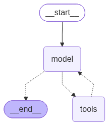

```python
from langchain.agents import create_agent
from IPython.display import Image, display

# 그래프 생성
answer_reviewer = create_agent(
    model=ChatOpenAI(model="gpt-4.1"),
    tools=tools,
    system_prompt=evaluation_prompt,
    )

# 그래프 출력
display(Image(answer_reviewer.get_graph().draw_mermaid_png()))
```

```python
# 그래프 실행
from langchain_core.messages import HumanMessage

messages = [HumanMessage(content=f"""<질문>\n{value['question']}\n</질문>\n<답변>\n{value['final_answer']}\n</답변>""")]
response = answer_reviewer.invoke({"messages": messages})
for m in response['messages']:
    m.pretty_print()
```

```
================================ Human Message =================================

<질문>
근로계약 체결할 때 개인정보 취급 상의 유의사항은 무엇인가요?
</질문>
<답변>
1. **핵심 답변**
근로계약 체결 시 개인정보 취급에 있어서는 다음과 같은 유의사항이 있습니다.
- 개인정보는 근로계약 목적에 필요한 최소한의 범위 내에서만 수집해야 하며, 정보주체(근로자)의 동의를 받거나 법률상 정당한 사유가 있어야 합니다.
- 개인정보 수집 시에는 수집·이용 목적, 수집 항목, 보유 및 이용 기간, 동의 거부 권리 및 불이익 여부를 명확히 고지해야 하며, 개인정보 처리방침을 수립·공개해야 합니다.
- 18세 미만 근로자의 경우, 연령을 증명할 수 있는 가족관계증명서와 친권자 또는 후견인의 동의서를 반드시 사업장에 비치·보관해야 하며, 근로조건을 서면 또는 전자문서로 명확히 명시하여 교부해야 합니다.
- 정보주체가 최소한의 정보 외 개인정보 수집에 동의하지 않는다고 하여 근로계약 체결이나 근로 조건에 불이익을 주어서는 안 됩니다.

2. **법적 근거**
- 개인정보 보호법
  - 제15조(개인정보의 수집·이용) 제1항, 제2항: 개인정보 수집은 동의 또는 법적 근거가 있어야 하며, 수집 목적·항목·보유 기간 등을 고지해야 함
  - 제16조(개인정보의 수집 제한) 제1~3항: 최소한의 개인정보만 수집하고, 동의 거부 시 불이익 금지
  - 제30조: 개인정보 처리방침 수립·공개 의무
- 근로기준법
  - 제66조(연소자 증명서): 18세 미만 근로자의 연령 증명서 및 친권자 동의서 보관 의무
  - 제67조 ③: 18세 미만 근로자와 근로조건을 서면 또는 전자문서로 명확히 교부해야 함

3. **실무적 적용**
- 근로계약서 작성 시 주민등록번호, 연락처, 은행계좌번호 등 계약 이행에 필수적인 개인정보만 수집하고, 건강 상태 등 민감정보는 별도의 동의를 받아야 합니다.
- 개인정보 수집 시 근로자에게 수집 목적, 보유 기간, 동의 거부 권리 등을 서면 또는 전자문서로 명확히 안내하고, 개인정보 처리방침을 회사 홈페이지나 근로자가 쉽게 접근할 수 있는 곳에 공개합니다.
- 18세 미만 근로자 채용 시 가족관계증명서와 친권자 동의서를 반드시 확보·보관하며, 근로조건을 서면 또는 전자문서로 명확히 명시하여 근로자에게 교부합니다.
- 개인정보는 안전한 장소에 보관하고, 무단 열람·유출 방지를 위한 내부 관리체계를 갖춥니다.
- 근로자가 추가 개인정보 제공에 동의하지 않아도 근로계약 체결이나 근로 조건에 불이익을 주지 않도록 주의합니다.

4. **주의사항**
- 개인정보 수집 및 이용 목적과 범위를 명확히 하여 근로자에게 충분히 고지하고 동의를 받는 것이 중요합니다.
- 18세 미만 근로자의 개인정보는 민감정보로 분류되므로 더욱 엄격한 보안 관리가 필요합니다.
- 개인정보 처리방침과 근로계약서 내용이 상충할 경우 근로자에게 유리한 내용을 적용해야 합니다.
- 개인정보 유출 시 법적 책임과 신뢰 하락이 발생할 수 있으므로, 관련 법규를 철저히 준수해야 합니다.

---

**요약**: 근로계약 체결 시 개인정보는 법적 근거에 따라 최소한으로 수집하고, 수집 목적과 권리를 명확히 고지하며, 18세 미만 근로자의 경우 연령 증명서류와 친권자 동의서를 반드시 보관해야 합니다. 또한 개인정보 처리방침을 수립·공개하고, 동의하지 않는 경우 불이익을 주지 않아야 하며, 개인정보 보호를 위한 안전한 관리가 필수적입니다.
(출처: 개인정보 보호법 제15조, 제16조, 제30조 / 근로기준법 제66조, 제67조 ③, 복수 출처 종합)
</답변>
================================== Ai Message ==================================

{
  "scores": {
    "accuracy": 10,
    "relevance": 10,
    "completeness": 10,
    "citation_accuracy": 9,
    "clarity_conciseness": 9,
    "objectivity": 10
  },
  "total_score": 58,
  "brief_evaluation": "답변은 법적·실무적 사항을 모두 포괄하며, 질의에 충실히 대응했습니다. 각 조문을 명확히 언급하고 근거도 적절합니다. 복잡한 내용을 구성적으로 잘 정리하였으나, 조문 표기 일부(예: '근로기준법 제67조 ③' 표기는 '제67조 제3항'이 권장됨) 등 약간의 형식 오류만 보입니다. 전반적으로 매우 우수한 답변입니다."
}
```

```python
pprint(json.loads(m.content))
```

```
{'brief_evaluation': '답변은 법적·실무적 사항을 모두 포괄하며, 질의에 충실히 대응했습니다. 각 조문을 명확히 언급하고 '
                     "근거도 적절합니다. 복잡한 내용을 구성적으로 잘 정리하였으나, 조문 표기 일부(예: '근로기준법 "
                     "제67조 ③' 표기는 '제67조 제3항'이 권장됨) 등 약간의 형식 오류만 보입니다. 전반적으로 매우 "
                     '우수한 답변입니다.',
 'scores': {'accuracy': 10,
            'citation_accuracy': 9,
            'clarity_conciseness': 9,
            'completeness': 10,
            'objectivity': 10,
            'relevance': 10},
 'total_score': 58}
```

### 5-2. 답변 평가 내용을 확인하는 HITL 추가

```python
from langgraph.types import interrupt, Command
from langchain_core.messages import HumanMessage

# 답변 평가하는 노드를 추가
def evaluate_answer_node(state:ResearchAgentState):
    question = state["question"]
    final_answer = state["final_answer"]

    messages = [HumanMessage(content=f"""[질문]\n{question}\n[답변]\n{final_answer}""")]
    response = answer_reviewer.invoke({"messages": messages})
    response_dict = json.loads(response['messages'][-1].content)

    return {"evaluation_report": response_dict, "question": question, "final_answer": final_answer}


# interrupt를 사용한 HITL 노드
def human_review_node(state: ResearchAgentState):
    """interrupt를 사용한 사람의 검토 노드"""

    # 사용자에게 표시할 정보 구성
    review_data = {
        "question": state["question"],
        "final_answer": state["final_answer"],
        "evaluation_report": state["evaluation_report"],
        "total_score": state["evaluation_report"].get("total_score", 0),
        "brief_evaluation": state["evaluation_report"].get("brief_evaluation", ""),
        "instruction": "답변을 검토해주세요 (approve/reject):"
    }

    print(f"\n현재 답변: {state['final_answer']}")
    print(f"평가 결과: 총점 {state['evaluation_report']['total_score']}/60")
    print(f"{state['evaluation_report']['brief_evaluation']}")

    # interrupt를 사용하여 사용자 입력 대기
    user_input = interrupt(value=review_data)

    # 사용자 입력 처리 개선
    if isinstance(user_input, dict):
        decision = user_input.get("decision", "").lower()
        feedback = user_input.get("feedback", "")
    elif isinstance(user_input, str):
        if user_input.lower() in ['y', 'yes', 'approve', 'approved', 'ok']:
            decision = "approved"
            feedback = ""
        else:
            decision = "rejected"
            feedback = user_input if user_input else "답변이 거부되었습니다."
    else:
        # 빈 입력이나 None인 경우 기본값 설정
        decision = "rejected"
        feedback = "입력이 없어 자동으로 거부되었습니다."

    return {
        "user_decision": decision,
        "user_feedback": feedback,
        "iteration_count": state.get("iteration_count", 0) + 1
    }


# 조건부 라우팅 함수
def route_after_human_review(state: ResearchAgentState) -> Literal["approved", "rejected"]:
    """human_review 노드 후 라우팅 결정"""
    user_decision = state.get("user_decision", "").lower()

    if user_decision in ["approved", "approve", "y", "yes"]:
        return "approved"
    else:
        return "rejected"

# 승인된 경우 처리하는 노드
def approved_node(state: ResearchAgentState):
    """답변이 승인된 경우의 최종 처리"""
    print("✅ 답변이 승인되었습니다!")
    return {
        "user_decision": "approved",
        "final_answer": state["final_answer"]
    }

# 거부된 경우 처리하는 노드
def rejected_node(state: ResearchAgentState):
    """답변이 거부된 경우의 처리"""
    print(f"❌ 답변이 거부되었습니다. 피드백: {state.get('user_feedback', '')}")

    # 최대 반복 횟수 체크 (예: 3회)
    if state.get("iteration_count", 0) >= 3:
        print("최대 반복 횟수에 도달했습니다. 현재 답변으로 진행합니다.")
        return {"final_answer": f"[최대 수정 후 자동 승인] {state['final_answer']}"}


    return {
        "user_feedback": state.get("user_feedback", ""),
        "iteration_count": state.get("iteration_count", 0)
    }
```

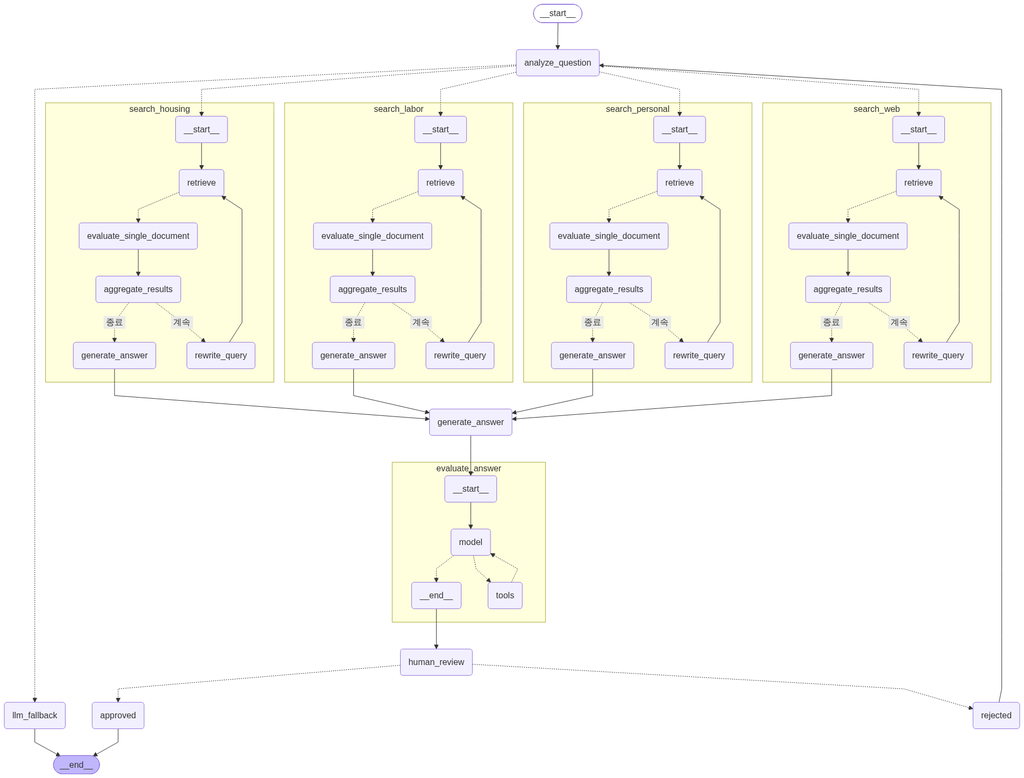

```python
from langgraph.checkpoint.memory import InMemorySaver

# 노드 정의
nodes = {
    "analyze_question": analyze_question_tool_search,
    "search_personal": personal_rag_node,
    "search_labor": labor_rag_node,
    "search_housing": housing_rag_node,
    "search_web": web_rag_node,
    "generate_answer": answer_final,
    "llm_fallback": llm_fallback,
    "evaluate_answer": evaluate_answer_node,
    "human_review": human_review_node,
    "approved": approved_node,
    "rejected": rejected_node,  # 거부 처리 노드 추가
}

# StateGraph 생성
search_builder = StateGraph(ResearchAgentState)

# 노드 추가
for node_name, node_func in nodes.items():
    search_builder.add_node(node_name, node_func)

# 엣지 추가
search_builder.add_edge(START, "analyze_question")

# 조건부 엣지 - 데이터 소스 라우팅
search_builder.add_conditional_edges(
    "analyze_question",
    route_datasources_tool_search,
    ["search_personal", "search_labor", "search_housing", "search_web", "llm_fallback"]
)

# 검색 노드들을 generate_answer에 연결
for node in ["search_personal", "search_labor", "search_housing", "search_web"]:
    search_builder.add_edge(node, "generate_answer")

search_builder.add_edge("generate_answer", "evaluate_answer")
search_builder.add_edge("evaluate_answer", "human_review")

# HITL 결과에 따른 조건부 엣지 - 수정된 부분
search_builder.add_conditional_edges(
    "human_review",
    route_after_human_review,
    {
        "approved": "approved",  # approved 노드로 이동
        "rejected": "rejected"   # rejected 노드로 이동
    }
)

# 최종 엣지들
search_builder.add_edge("approved", END)
search_builder.add_edge("rejected", "analyze_question")  # 거부 시 처음부터 다시 시작
search_builder.add_edge("llm_fallback", END)

# 메모리 추가 (interrupt 사용을 위해 필수)
checkpointer = InMemorySaver()

# 그래프 컴파일
legal_rag_agent = search_builder.compile(checkpointer=checkpointer)

# 그래프 시각화
display(Image(legal_rag_agent.get_graph(xray=True).draw_mermaid_png()))
```

```python
# 질문 입력
inputs = {"question": "대리인과 아파트 임대차 계약을 체결할 때 주의해야 할 점은 무엇인가요?"}

# 스레드 설정
thread_config = {
    "configurable": {
        "thread_id": "legal_rag_thread",
    }
}
for output in legal_rag_agent.stream(inputs, config=thread_config):
    for key, value in output.items():
        # 노드 출력
        pprint(f"Node '{key}':")
        pprint(f"Value: {value}", indent=2, width=80, depth=None)
    print("\n----------------------------------------------------------\n")
```

````
도구 선택을 위해 질문 분석 중: 대리인과 아파트 임대차 계약을 체결할 때 주의해야 할 점은 무엇인가요?
선택된 도구들: ['search_housing']
"Node 'analyze_question':"
"Value: {'datasources': ['search_housing'], 'agent_responses': {}}"

----------------------------------------------------------

--- 주택임대차보호법 전문가 에이전트 시작 ---
---주택임대차보호법 문서 검색---
---주택임대차보호법 관련 4개 문서에 대한 평가 병렬 워커 생성---
---주택임대차보호법 관련 단일 문서 처리 중 (길이: 437...)---
---주택임대차보호법 관련 단일 문서 처리 중 (길이: 1617...)---
---주택임대차보호법 관련 단일 문서 처리 중 (길이: 243...)---
---주택임대차보호법 관련 단일 문서 처리 중 (길이: 272...)---
문서 관련성이 낮음: 0.75
문서 관련성이 낮음: 0.75
고품질 정보 3개 추출됨
고품질 정보 4개 추출됨
---주택임대차보호법 관련 총 7개의 정보 조각 집계---
EmbeddingsRedundantFilter 중복 제거: 7 → 7개
최종 결과: 7 → 7  → 7개
---주택임대차보호법 답변 생성---
"Node 'search_housing':"
("Value: {'answers': ['```markdown\\n# 대리인과 아파트 임대차 계약 체결 시 주의사항\\n\\n## 1. "
 '질문에 대한 직접적인 답변\\n대리인을 통해 아파트 임대차 계약을 체결할 때는 임대인의 명확한 동의 여부를 반드시 확인해야 합니다. '
 '특히, 임대인의 동의 없이 목적 주택의 전부 또는 일부를 전대하는 경우, 임차인은 계약갱신 요구가 거절될 수 있으므로 주의가 필요합니다. '
 '또한, 임대인은 임차인에게 확정일자, 차임, 보증금 등의 정보를 제공해야 하며, 임대인의 권한과 책임 범위를 명확히 하여 분쟁을 예방해야 '
 '합니다.\\n\\n## 2. 관련 법률 조항 및 해석\\n- **주택임대차보호법 제6조의3 제1항 4호**  \\n  대리인이 임대인의 '
 '동의 없이 목적 주택의 전부 또는 일부를 전대하는 경우, 임차인의 계약갱신 요구가 거절될 수 있음을 명시하고 있습니다.  \\n  '
 '(출처: 주택임대차보호법 제6조의3 제1항 4호)\\n\\n- **주택임대차보호법 제6조의3 제1항 전단**  \\n  임대인은 임차인의 '
 '계약갱신 요구를 정당한 사유 없이 거절할 수 없으며, 대리인 계약 시 임대인의 동의 여부가 중요하다고 규정합니다.  \\n  (출처: '
 '주택임대차보호법 제6조의3 제1항 전단)\\n\\n- **주택임대차보호법 제3조의7**  \\n  임대인은 임차인에게 확정일자 부여일, '
 '차임, 보증금 등의 정보를 제공해야 하며, 국세 및 지방세 납세증명서 제출 또는 미납액 열람 동의 절차를 거쳐야 합니다.  \\n  '
 '(출처: 주택임대차보호법 제3조의7)\\n\\n- **주택임대차보호법 제6조의3 제5항**  \\n  임대인이 계약갱신 요구를 부당하게 '
 '거절할 경우 임차인에게 손해배상 책임이 발생할 수 있으므로, 대리인 계약 시 임대인의 권한과 책임을 명확히 해야 합니다.  \\n  '
 '(출처: 주택임대차보호법 제6조의3 제5항)\\n\\n## 3. 추가 설명 또는 예시\\n- **임대인의 동의 확인**  \\n  '
 '대리인이 계약을 체결할 때 임대인의 위임장이나 명확한 동의서가 필요합니다. 동의 없이 계약을 체결하면 임대차 계약의 안정성이 저해될 수 '
 '있습니다.\\n\\n- **전대 금지 주의**  \\n  임대인의 동의 없이 임차인이 전대할 경우, 임대인은 계약갱신을 거절할 수 '
 '있으므로 임차인은 전대 여부를 사전에 확인해야 합니다.\\n\\n- **정보 제공 의무**  \\n  임대인은 임차인에게 계약 조건과 '
 '관련된 중요한 정보를 투명하게 제공해야 하며, 이를 통해 임차인의 권리를 보호합니다.\\n\\n- **책임 소재 명확화**  \\n  '
````

[output cut: 142 more lines]

```
 '필수적입니다.\\n\\n---\\n\\n**요약**: 대리인을 통한 아파트 임대차 계약 체결 시에는 임대인의 명확한 동의와 권한 범위 '
 '확인, 임차인에 대한 계약 조건 정보 제공, 전대 여부 확인, 그리고 계약갱신 거절 시 손해배상 책임 문제를 충분히 고려해야 하며, 이를 '
 "통해 법적 분쟁을 예방하고 계약의 안정성을 확보할 수 있습니다.  \\n\\n(출처: 주택임대차보호법 제3조의7, 제6조의3)', "
 "'evaluation_report': {'scores': {'accuracy': 10, 'relevance': 10, "
 "'completeness': 10, 'citation_accuracy': 10, 'clarity_conciseness': 9, "
 '\'objectivity\': 10}, \'total_score\': 59, \'brief_evaluation\': "답변은 대리인을 '
 '통한 임대차 계약 체결 시의 주의사항을 법적·실무적으로 상세하고 체계적으로 설명하며, 관련 법 조항도 옳게 제시했습니다. 분명하고 '
 "체계적이나 일부 반복적 표현과 길이가 있어 '명확성·간결성'만 1점 감점했습니다. 전반적으로 정확하고 신뢰할 수 있는 매우 우수한 "
 '답변입니다."}, \'total_score\': 59, \'brief_evaluation\': "답변은 대리인을 통한 임대차 계약 체결 '
 '시의 주의사항을 법적·실무적으로 상세하고 체계적으로 설명하며, 관련 법 조항도 옳게 제시했습니다. 분명하고 체계적이나 일부 반복적 표현과 '
 '길이가 있어 \'명확성·간결성\'만 1점 감점했습니다. 전반적으로 정확하고 신뢰할 수 있는 매우 우수한 답변입니다.", '
 "'instruction': '답변을 검토해주세요 (approve/reject):'}, "
 "id='87c39834f2e1bfe0c01d250374cf4ef7'),)")

----------------------------------------------------------
```

```python
# 현재 중단된 노드 확인
key
```

```
'__interrupt__'
```

```python
# 중단점의 상태 값 확인
pprint(value[0].value)
```

```
{'brief_evaluation': '답변은 대리인을 통한 임대차 계약 체결 시의 주의사항을 법적·실무적으로 상세하고 체계적으로 설명하며, '
                     '관련 법 조항도 옳게 제시했습니다. 분명하고 체계적이나 일부 반복적 표현과 길이가 있어 '
                     "'명확성·간결성'만 1점 감점했습니다. 전반적으로 정확하고 신뢰할 수 있는 매우 우수한 답변입니다.",
 'evaluation_report': {'brief_evaluation': '답변은 대리인을 통한 임대차 계약 체결 시의 주의사항을 '
                                           '법적·실무적으로 상세하고 체계적으로 설명하며, 관련 법 조항도 '
                                           '옳게 제시했습니다. 분명하고 체계적이나 일부 반복적 표현과 '
                                           "길이가 있어 '명확성·간결성'만 1점 감점했습니다. 전반적으로 "
                                           '정확하고 신뢰할 수 있는 매우 우수한 답변입니다.',
                       'scores': {'accuracy': 10,
                                  'citation_accuracy': 10,
                                  'clarity_conciseness': 9,
                                  'completeness': 10,
                                  'objectivity': 10,
                                  'relevance': 10},
                       'total_score': 59},
 'final_answer': '1. **핵심 답변**  \n'
                 '대리인을 통해 아파트 임대차 계약을 체결할 때는 반드시 임대인의 명확한 동의 여부를 확인해야 하며, 임대인의 '
                 '위임장이나 동의서 등 공식적인 증빙을 확보하는 것이 중요합니다. 임대인의 동의 없이 계약을 체결하거나 목적 '
                 '주택의 전부 또는 일부를 전대하는 경우, 임차인은 계약갱신 요구가 거절될 수 있으므로 주의해야 합니다. '
                 '또한, 임대인은 임차인에게 확정일자, 차임, 보증금 등 계약 관련 중요한 정보를 투명하게 제공해야 하며, '
                 '대리인 계약 시 임대인의 권한과 책임 범위를 명확히 하여 분쟁과 손해배상 문제를 예방해야 합니다.\n'
                 '\n'
                 '2. **법적 근거**  \n'
                 '- **주택임대차보호법 제6조의3 제1항 4호**: 대리인이 임대인의 동의 없이 목적 주택의 전부 또는 '
                 '일부를 전대하는 경우 임차인의 계약갱신 요구가 거절될 수 있음을 규정  \n'
                 '- **주택임대차보호법 제6조의3 제1항 전단**: 임대인은 임차인의 계약갱신 요구를 정당한 사유 없이 '
                 '거절할 수 없으며, 대리인 계약 시 임대인의 동의 여부가 중요함  \n'
                 '- **주택임대차보호법 제3조의7**: 임대인은 임차인에게 확정일자 부여일, 차임, 보증금 등의 정보를 '
                 '제공해야 하며, 국세 및 지방세 납세증명서 제출 또는 미납액 열람 동의 절차를 거쳐야 함  \n'
                 '- **주택임대차보호법 제6조의3 제5항**: 임대인이 계약갱신 요구를 부당하게 거절할 경우 임차인에게 '
                 '손해배상 책임이 발생할 수 있으므로, 대리인 계약 시 권한과 책임을 명확히 해야 함\n'
                 '\n'
                 '3. **실무적 적용**  \n'
                 '- **임대인의 동의 확인**: 대리인이 계약을 체결할 때는 임대인의 위임장이나 동의서를 반드시 확인하고 '
                 '보관해야 하며, 임대인의 동의 없이 계약을 진행하지 않아야 합니다.  \n'
                 '- **전대 여부 확인**: 임차인이 임대인의 동의 없이 전대하는 경우 계약갱신이 거절될 수 있으므로, 전대 '
                 '가능 여부를 사전에 명확히 확인해야 합니다.  \n'
                 '- **정보 제공 및 투명성 확보**: 임대인은 임차인에게 계약 조건(확정일자, 보증금, 차임 등)을 명확히 '
                 '알리고, 관련 세금 납부 증명서 제출 등 절차를 성실히 이행해야 합니다.  \n'
                 '- **권한과 책임 명확화**: 대리인 계약 시 임대인의 권한 범위와 책임 소재를 문서로 명확히 하여, '
                 '계약갱신 거절 시 발생할 수 있는 분쟁과 손해배상 문제를 예방합니다.\n'
                 '\n'
                 '4. **최신 동향 및 주의사항**  \n'
                 '- 최근 법령 및 판례는 대리인 계약 시 임대인의 동의와 권한 범위 확인을 더욱 엄격히 요구하고 있어, '
                 '임대차 계약의 안정성을 확보하기 위한 절차 준수가 중요합니다.  \n'
                 '- 임대인의 동의 없이 전대하거나 계약을 체결할 경우 임차인의 권리가 제한될 수 있으므로, 계약 전 반드시 '
                 '임대인의 동의 여부를 확인하는 것이 필수적입니다.\n'
                 '\n'
                 '---\n'
                 '\n'
                 '**요약**: 대리인을 통한 아파트 임대차 계약 체결 시에는 임대인의 명확한 동의와 권한 범위 확인, '
                 '임차인에 대한 계약 조건 정보 제공, 전대 여부 확인, 그리고 계약갱신 거절 시 손해배상 책임 문제를 충분히 '
                 '고려해야 하며, 이를 통해 법적 분쟁을 예방하고 계약의 안정성을 확보할 수 있습니다.  \n'
                 '\n'
                 '(출처: 주택임대차보호법 제3조의7, 제6조의3)',
 'instruction': '답변을 검토해주세요 (approve/reject):',
 'question': '대리인과 아파트 임대차 계약을 체결할 때 주의해야 할 점은 무엇인가요?',
 'total_score': 59}
```

- **사용자 개입 (HITL): 거부**
  - 사용자가 승인을 해주지 않는 경우, 피드백을 통해 다시 생성
  - **Command** 함수로 사용자 피드백 전달

```python
from langgraph.types import Command

# 사용자 피드백 제공 (거부)
human_feedback = {
    "decision": "rejected",
    "feedback": "답변에 대한 출처가 충분히 구체적이지 않습니다. 인용된 법조항에 대한 구체적 조문과 더 많은 세부사항이 필요합니다."
}

# 사용자 입력으로 그래프 재개
for output in legal_rag_agent.stream(Command(resume=human_feedback), config=thread_config):
    for key, value in output.items():
        # 노드 출력
        pprint(f"Node '{key}':")
        pprint(f"Value: {value}", indent=2, width=80, depth=None)
    print("\n----------------------------------------------------------\n")
```

```
현재 답변: 1. **핵심 답변**
대리인을 통해 아파트 임대차 계약을 체결할 때는 반드시 임대인의 명확한 동의 여부를 확인해야 하며, 임대인의 위임장이나 동의서 등 공식적인 증빙을 확보하는 것이 중요합니다. 임대인의 동의 없이 계약을 체결하거나 목적 주택의 전부 또는 일부를 전대하는 경우, 임차인은 계약갱신 요구가 거절될 수 있으므로 주의해야 합니다. 또한, 임대인은 임차인에게 확정일자, 차임, 보증금 등 계약 관련 중요한 정보를 투명하게 제공해야 하며, 대리인 계약 시 임대인의 권한과 책임 범위를 명확히 하여 분쟁과 손해배상 문제를 예방해야 합니다.

2. **법적 근거**
- **주택임대차보호법 제6조의3 제1항 4호**: 대리인이 임대인의 동의 없이 목적 주택의 전부 또는 일부를 전대하는 경우 임차인의 계약갱신 요구가 거절될 수 있음을 규정
- **주택임대차보호법 제6조의3 제1항 전단**: 임대인은 임차인의 계약갱신 요구를 정당한 사유 없이 거절할 수 없으며, 대리인 계약 시 임대인의 동의 여부가 중요함
- **주택임대차보호법 제3조의7**: 임대인은 임차인에게 확정일자 부여일, 차임, 보증금 등의 정보를 제공해야 하며, 국세 및 지방세 납세증명서 제출 또는 미납액 열람 동의 절차를 거쳐야 함
- **주택임대차보호법 제6조의3 제5항**: 임대인이 계약갱신 요구를 부당하게 거절할 경우 임차인에게 손해배상 책임이 발생할 수 있으므로, 대리인 계약 시 권한과 책임을 명확히 해야 함

3. **실무적 적용**
- **임대인의 동의 확인**: 대리인이 계약을 체결할 때는 임대인의 위임장이나 동의서를 반드시 확인하고 보관해야 하며, 임대인의 동의 없이 계약을 진행하지 않아야 합니다.
- **전대 여부 확인**: 임차인이 임대인의 동의 없이 전대하는 경우 계약갱신이 거절될 수 있으므로, 전대 가능 여부를 사전에 명확히 확인해야 합니다.
- **정보 제공 및 투명성 확보**: 임대인은 임차인에게 계약 조건(확정일자, 보증금, 차임 등)을 명확히 알리고, 관련 세금 납부 증명서 제출 등 절차를 성실히 이행해야 합니다.
- **권한과 책임 명확화**: 대리인 계약 시 임대인의 권한 범위와 책임 소재를 문서로 명확히 하여, 계약갱신 거절 시 발생할 수 있는 분쟁과 손해배상 문제를 예방합니다.

4. **최신 동향 및 주의사항**
- 최근 법령 및 판례는 대리인 계약 시 임대인의 동의와 권한 범위 확인을 더욱 엄격히 요구하고 있어, 임대차 계약의 안정성을 확보하기 위한 절차 준수가 중요합니다.
- 임대인의 동의 없이 전대하거나 계약을 체결할 경우 임차인의 권리가 제한될 수 있으므로, 계약 전 반드시 임대인의 동의 여부를 확인하는 것이 필수적입니다.

---

**요약**: 대리인을 통한 아파트 임대차 계약 체결 시에는 임대인의 명확한 동의와 권한 범위 확인, 임차인에 대한 계약 조건 정보 제공, 전대 여부 확인, 그리고 계약갱신 거절 시 손해배상 책임 문제를 충분히 고려해야 하며, 이를 통해 법적 분쟁을 예방하고 계약의 안정성을 확보할 수 있습니다.

(출처: 주택임대차보호법 제3조의7, 제6조의3)
평가 결과: 총점 59/60
답변은 대리인을 통한 임대차 계약 체결 시의 주의사항을 법적·실무적으로 상세하고 체계적으로 설명하며, 관련 법 조항도 옳게 제시했습니다. 분명하고 체계적이나 일부 반복적 표현과 길이가 있어 '명확성·간결성'만 1점 감점했습니다. 전반적으로 정확하고 신뢰할 수 있는 매우 우수한 답변입니다.
"Node 'human_review':"
("Value: {'user_decision': 'rejected', 'user_feedback': '답변에 대한 출처가 충분히 구체적이지 "
 "않습니다. 인용된 법조항에 대한 구체적 조문과 더 많은 세부사항이 필요합니다.', 'iteration_count': 1}")

----------------------------------------------------------

❌ 답변이 거부되었습니다. 피드백: 답변에 대한 출처가 충분히 구체적이지 않습니다. 인용된 법조항에 대한 구체적 조문과 더 많은 세부사항이 필요합니다.
"Node 'rejected':"
("Value: {'user_feedback': '답변에 대한 출처가 충분히 구체적이지 않습니다. 인용된 법조항에 대한 구체적 조문과 더 "
 "많은 세부사항이 필요합니다.', 'iteration_count': 1}")

----------------------------------------------------------

도구 선택을 위해 질문 분석 중: 대리인과 아파트 임대차 계약을 체결할 때 주의해야 할 점은 무엇인가요?
```

[output cut: 212 more lines]

```
 '모두 관련 법률 조항을 숙지해야 합니다.\\n\\n---\\n\\n**참고 법조문**  \\n- 주택임대차보호법 제3조의7(임대인의 정보 '
 '제공 의무)  \\n- 주택임대차보호법 제6조의3(계약갱신 요구 및 거절 사유)  \\n- 주택임대차보호법 제30조(주택임대차표준계약서 '
 '사용)  \\n- 주택임대차보호법 관련 판례 및 법률 해석(대리권 증빙)  \\n\\n(출처: 주택임대차보호법 제3조의7, 제6조의3, '
 "제30조, 관련 판례 및 법률 해석 종합)', 'evaluation_report': {'scores': {'accuracy': 9, "
 "'relevance': 10, 'completeness': 10, 'citation_accuracy': 7, "
 "'clarity_conciseness': 9, 'objectivity': 10}, 'total_score': 55, "
 "'brief_evaluation': '답변은 실제로 대리인과 임대차계약 체결 시 거의 모든 핵심 유의사항 및 실무상 문제점을 잘 짚었고, "
 '법령 조항도 제시해 근거를 명확히 하였습니다. 다만 판례 및 법률 해석을 일반적으로 언급하면서 구체적 근거·출처가 명확하지 않아 인용의 '
 "정확성에서 일부 감점하였습니다. 전체적으로 신뢰할 만한 안내입니다.'}, 'total_score': 55, "
 "'brief_evaluation': '답변은 실제로 대리인과 임대차계약 체결 시 거의 모든 핵심 유의사항 및 실무상 문제점을 잘 짚었고, "
 '법령 조항도 제시해 근거를 명확히 하였습니다. 다만 판례 및 법률 해석을 일반적으로 언급하면서 구체적 근거·출처가 명확하지 않아 인용의 '
 "정확성에서 일부 감점하였습니다. 전체적으로 신뢰할 만한 안내입니다.', 'instruction': '답변을 검토해주세요 "
 "(approve/reject):'}, id='d66c2753c02fd83e8f2ff61a3e0c7134'),)")

----------------------------------------------------------
```

```python
# 현재 상태 - 그래프 체크포인트 확인
current_state = legal_rag_agent.get_state(thread_config)

print(f"\n현재 상태: {current_state.values}")
print(f"대기 중인 interrupt: {current_state.tasks}")
```

````
현재 상태: {'question': '대리인과 아파트 임대차 계약을 체결할 때 주의해야 할 점은 무엇인가요?', 'answers': ['```markdown\n# 대리인과 아파트 임대차 계약 체결 시 주의사항\n\n## 1. 질문에 대한 직접적인 답변\n대리인을 통해 아파트 임대차 계약을 체결할 때는 임대인의 명확한 동의 여부를 반드시 확인해야 합니다. 특히, 임대인의 동의 없이 목적 주택의 전부 또는 일부를 전대하는 경우, 임차인은 계약갱신 요구가 거절될 수 있으므로 주의가 필요합니다. 또한, 임대인은 임차인에게 확정일자, 차임,…
대기 중인 interrupt: (PregelTask(id='75c4057b-093e-6f54-8228-fe8dd04b858b', name='human_review', path=('__pregel_pull', 'human_review'), error=None, interrupts=(Interrupt(value={'question': '대리인과 아파트 임대차 계약을 체결할 때 주의해야 할 점은 무엇인가요?', 'final_answer': '1. **핵심 답변**  \n대리인과 아파트 임대차 계약을 체결할 때는 반드시 대리권을 증명하는 …
````

```python
# 대기 중인 interrupt 확인
task = current_state.tasks[0]
print(task.id)
print(task.name)
pprint(task.interrupts[0].value)
```

```
75c4057b-093e-6f54-8228-fe8dd04b858b
human_review
{'brief_evaluation': '답변은 실제로 대리인과 임대차계약 체결 시 거의 모든 핵심 유의사항 및 실무상 문제점을 잘 짚었고, '
                     '법령 조항도 제시해 근거를 명확히 하였습니다. 다만 판례 및 법률 해석을 일반적으로 언급하면서 구체적 '
                     '근거·출처가 명확하지 않아 인용의 정확성에서 일부 감점하였습니다. 전체적으로 신뢰할 만한 안내입니다.',
 'evaluation_report': {'brief_evaluation': '답변은 실제로 대리인과 임대차계약 체결 시 거의 모든 핵심 '
                                           '유의사항 및 실무상 문제점을 잘 짚었고, 법령 조항도 제시해 '
                                           '근거를 명확히 하였습니다. 다만 판례 및 법률 해석을 '
                                           '일반적으로 언급하면서 구체적 근거·출처가 명확하지 않아 인용의 '
                                           '정확성에서 일부 감점하였습니다. 전체적으로 신뢰할 만한 '
                                           '안내입니다.',
                       'scores': {'accuracy': 9,
                                  'citation_accuracy': 7,
                                  'clarity_conciseness': 9,
                                  'completeness': 10,
                                  'objectivity': 10,
                                  'relevance': 10},
                       'total_score': 55},
 'final_answer': '1. **핵심 답변**  \n'
                 '대리인과 아파트 임대차 계약을 체결할 때는 반드시 대리권을 증명하는 위임장 등 서류를 확인하여 계약의 법적 '
                 '효력을 확보해야 합니다. 또한, 임대인이 임차인에게 제공해야 하는 정보(확정일자 부여일, 차임, 보증금, '
                 '납세증명서 등)가 제대로 이행되었는지 꼼꼼히 점검해야 하며, 계약서에는 임대차 조건을 명확히 기재해야 '
                 '합니다. 계약갱신 요구권과 임대인의 정당한 거절 사유를 사전에 숙지하여 분쟁을 예방하는 것도 중요합니다. '
                 '표준계약서 사용을 권장하며, 임대인의 정보 제공 의무 불이행이나 대리권 미확인으로 인한 법적 분쟁에 주의해야 '
                 '합니다.\n'
                 '\n'
                 '2. **법적 근거**  \n'
                 '- **대리권 증빙 확인**: 대리인과 계약 시 위임장 등 대리권 증빙서류를 반드시 확인해야 하며, 이를 '
                 '통해 계약의 법적 효력이 인정됩니다. (주택임대차보호법 관련 판례 및 법률 해석)  \n'
                 '- **임대인의 정보 제공 의무**: 임대인은 임대차 계약 체결 시 임차인에게 확정일자 부여일, 차임, '
                 '보증금, 국세 및 지방세 납세증명서 등을 제공해야 하며, 임대인이 동의하면 일부 서류 제출을 갈음할 수 '
                 '있습니다. (주택임대차보호법 제3조의7)  \n'
                 '- **계약갱신 요구 및 정당한 거절 사유**: 임차인이 계약갱신을 요구할 경우 임대인은 정당한 사유 없이 '
                 '거절할 수 없으며, 거절 사유에는 차임 연체, 부정한 임차, 임대인의 동의 없는 전대, 주택 파손 등이 '
                 '포함됩니다. (주택임대차보호법 제6조의3 제1항~제4항)  \n'
                 '- **계약서 작성 및 표준계약서 사용 권장**: 임대차 계약은 서면으로 체결하는 것이 원칙이며, '
                 '법무부장관과 국토교통부장관이 협의하여 정한 주택임대차표준계약서를 우선적으로 사용하는 것이 권장됩니다. '
                 '(주택임대차보호법 제30조)\n'
                 '\n'
                 '3. **실무적 적용**  \n'
```

[output cut: 20 more lines]

```
                 '- 계약갱신 거절 사유가 정당하지 않으면 임대인이 손해배상 책임을 질 수 있으므로 임대인과 임차인 모두 관련 '
                 '법률 조항을 숙지해야 합니다.\n'
                 '\n'
                 '---\n'
                 '\n'
                 '**참고 법조문**  \n'
                 '- 주택임대차보호법 제3조의7(임대인의 정보 제공 의무)  \n'
                 '- 주택임대차보호법 제6조의3(계약갱신 요구 및 거절 사유)  \n'
                 '- 주택임대차보호법 제30조(주택임대차표준계약서 사용)  \n'
                 '- 주택임대차보호법 관련 판례 및 법률 해석(대리권 증빙)  \n'
                 '\n'
                 '(출처: 주택임대차보호법 제3조의7, 제6조의3, 제30조, 관련 판례 및 법률 해석 종합)',
 'instruction': '답변을 검토해주세요 (approve/reject):',
 'question': '대리인과 아파트 임대차 계약을 체결할 때 주의해야 할 점은 무엇인가요?',
 'total_score': 55}
```

```python
# 다음에 실행될 노드를 확인
current_state.next
```

```
('human_review',)
```

- **사용자 개입 (HITL): 승인**
- 사용자가 '승인'을 해서 최종 답변을 생성하고 종료

```python
from langgraph.types import Command

# 사용자 피드백 제공 (승인 문자열을 사용)
human_feedback = "approved"

# 사용자 입력으로 그래프 재개
for output in legal_rag_agent.stream(Command(resume=human_feedback), config=thread_config):
    for key, value in output.items():
        # 노드 출력
        pprint(f"Node '{key}':")
        pprint(f"Value: {value}", indent=2, width=80, depth=None)
    print("\n----------------------------------------------------------\n")
```

```
현재 답변: 1. **핵심 답변**
대리인과 아파트 임대차 계약을 체결할 때는 반드시 대리권을 증명하는 위임장 등 서류를 확인하여 계약의 법적 효력을 확보해야 합니다. 또한, 임대인이 임차인에게 제공해야 하는 정보(확정일자 부여일, 차임, 보증금, 납세증명서 등)가 제대로 이행되었는지 꼼꼼히 점검해야 하며, 계약서에는 임대차 조건을 명확히 기재해야 합니다. 계약갱신 요구권과 임대인의 정당한 거절 사유를 사전에 숙지하여 분쟁을 예방하는 것도 중요합니다. 표준계약서 사용을 권장하며, 임대인의 정보 제공 의무 불이행이나 대리권 미확인으로 인한 법적 분쟁에 주의해야 합니다.

2. **법적 근거**
- **대리권 증빙 확인**: 대리인과 계약 시 위임장 등 대리권 증빙서류를 반드시 확인해야 하며, 이를 통해 계약의 법적 효력이 인정됩니다. (주택임대차보호법 관련 판례 및 법률 해석)
- **임대인의 정보 제공 의무**: 임대인은 임대차 계약 체결 시 임차인에게 확정일자 부여일, 차임, 보증금, 국세 및 지방세 납세증명서 등을 제공해야 하며, 임대인이 동의하면 일부 서류 제출을 갈음할 수 있습니다. (주택임대차보호법 제3조의7)
- **계약갱신 요구 및 정당한 거절 사유**: 임차인이 계약갱신을 요구할 경우 임대인은 정당한 사유 없이 거절할 수 없으며, 거절 사유에는 차임 연체, 부정한 임차, 임대인의 동의 없는 전대, 주택 파손 등이 포함됩니다. (주택임대차보호법 제6조의3 제1항~제4항)
- **계약서 작성 및 표준계약서 사용 권장**: 임대차 계약은 서면으로 체결하는 것이 원칙이며, 법무부장관과 국토교통부장관이 협의하여 정한 주택임대차표준계약서를 우선적으로 사용하는 것이 권장됩니다. (주택임대차보호법 제30조)

3. **실무적 적용**
- **대리인 확인 절차**: 임대인이 직접 계약하지 않고 대리인이 계약을 체결하는 경우, 임차인은 반드시 대리인이 임대인으로부터 위임받은 권한이 있는지 위임장 등 서류를 통해 확인해야 합니다. 이를 소홀히 하면 계약 무효 또는 분쟁 발생 위험이 있습니다.
- **임대인의 정보 제공 확인**: 임대인이 납세증명서 제출을 거부할 경우, 임차인은 계약 체결 전에 이에 대한 동의를 받거나 관련 서류를 요구하여 임대인의 신뢰성을 확인해야 합니다.
- **계약서 작성 시 주의사항**: 계약서에는 보증금, 차임, 계약 기간, 확정일자 부여일 등 임대차 조건을 명확히 기재하고, 표준계약서 양식을 활용하는 것이 분쟁 예방에 효과적입니다.
- **계약갱신 거절 시 책임**: 임대인이 정당한 사유 없이 계약갱신 요구를 거절하고 제3자에게 임대할 경우, 임대인은 임차인에게 손해배상 책임을 질 수 있으므로 주의해야 합니다.

4. **최신 동향**
최근 주택임대차보호법은 임차인의 권리 보호를 강화하는 방향으로 개정되어, 계약갱신 요구권과 임대인의 정보 제공 의무가 더욱 엄격해졌습니다. 이에 따라 대리인과 계약 시에도 위임장 등 대리권 증빙서류 확인과 임대인의 정보 제공 의무 이행 여부 점검이 더욱 중요해졌습니다.

5. **주의사항**
- 대리권이 명확하지 않은 경우 계약 무효 또는 분쟁 발생 가능성이 높으므로 반드시 서류를 통해 확인해야 합니다.
- 임대인의 정보 제공 의무가 제대로 이행되지 않으면 임차인의 권리 보호에 어려움이 있으므로 계약 전 꼼꼼히 확인해야 합니다.
- 계약갱신 거절 사유가 정당하지 않으면 임대인이 손해배상 책임을 질 수 있으므로 임대인과 임차인 모두 관련 법률 조항을 숙지해야 합니다.

---

**참고 법조문**
- 주택임대차보호법 제3조의7(임대인의 정보 제공 의무)
- 주택임대차보호법 제6조의3(계약갱신 요구 및 거절 사유)
- 주택임대차보호법 제30조(주택임대차표준계약서 사용)
- 주택임대차보호법 관련 판례 및 법률 해석(대리권 증빙)

(출처: 주택임대차보호법 제3조의7, 제6조의3, 제30조, 관련 판례 및 법률 해석 종합)
평가 결과: 총점 55/60
답변은 실제로 대리인과 임대차계약 체결 시 거의 모든 핵심 유의사항 및 실무상 문제점을 잘 짚었고, 법령 조항도 제시해 근거를 명확히 하였습니다. 다만 판례 및 법률 해석을 일반적으로 언급하면서 구체적 근거·출처가 명확하지 않아 인용의 정확성에서 일부 감점하였습니다. 전체적으로 신뢰할 만한 안내입니다.
"Node 'human_review':"
("Value: {'user_decision': 'approved', 'user_feedback': '', 'iteration_count': "
 '2}')

----------------------------------------------------------

```

[output cut: 17 more lines]

```
 '**임대인의 정보 제공 확인**: 임대인이 납세증명서 제출을 거부할 경우, 임차인은 계약 체결 전에 이에 대한 동의를 받거나 관련 서류를 '
 '요구하여 임대인의 신뢰성을 확인해야 합니다.  \\n- **계약서 작성 시 주의사항**: 계약서에는 보증금, 차임, 계약 기간, 확정일자 '
 '부여일 등 임대차 조건을 명확히 기재하고, 표준계약서 양식을 활용하는 것이 분쟁 예방에 효과적입니다.  \\n- **계약갱신 거절 시 '
 '책임**: 임대인이 정당한 사유 없이 계약갱신 요구를 거절하고 제3자에게 임대할 경우, 임대인은 임차인에게 손해배상 책임을 질 수 '
 '있으므로 주의해야 합니다.\\n\\n4. **최신 동향**  \\n최근 주택임대차보호법은 임차인의 권리 보호를 강화하는 방향으로 '
 '개정되어, 계약갱신 요구권과 임대인의 정보 제공 의무가 더욱 엄격해졌습니다. 이에 따라 대리인과 계약 시에도 위임장 등 대리권 증빙서류 '
 '확인과 임대인의 정보 제공 의무 이행 여부 점검이 더욱 중요해졌습니다.\\n\\n5. **주의사항**  \\n- 대리권이 명확하지 않은 '
 '경우 계약 무효 또는 분쟁 발생 가능성이 높으므로 반드시 서류를 통해 확인해야 합니다.  \\n- 임대인의 정보 제공 의무가 제대로 '
 '이행되지 않으면 임차인의 권리 보호에 어려움이 있으므로 계약 전 꼼꼼히 확인해야 합니다.  \\n- 계약갱신 거절 사유가 정당하지 않으면 '
 '임대인이 손해배상 책임을 질 수 있으므로 임대인과 임차인 모두 관련 법률 조항을 숙지해야 합니다.\\n\\n---\\n\\n**참고 '
 '법조문**  \\n- 주택임대차보호법 제3조의7(임대인의 정보 제공 의무)  \\n- 주택임대차보호법 제6조의3(계약갱신 요구 및 거절 '
 '사유)  \\n- 주택임대차보호법 제30조(주택임대차표준계약서 사용)  \\n- 주택임대차보호법 관련 판례 및 법률 해석(대리권 증빙)  '
 "\\n\\n(출처: 주택임대차보호법 제3조의7, 제6조의3, 제30조, 관련 판례 및 법률 해석 종합)'}")

----------------------------------------------------------
```

```python
# 현재 상태 - 그래프 체크포인트 확인
current_state = legal_rag_agent.get_state(thread_config)

print(f"\n현재 상태: {current_state.values}")
print(f"대기 중인 interrupt: {current_state.tasks}")
```

````
현재 상태: {'question': '대리인과 아파트 임대차 계약을 체결할 때 주의해야 할 점은 무엇인가요?', 'answers': ['```markdown\n# 대리인과 아파트 임대차 계약 체결 시 주의사항\n\n## 1. 질문에 대한 직접적인 답변\n대리인을 통해 아파트 임대차 계약을 체결할 때는 임대인의 명확한 동의 여부를 반드시 확인해야 합니다. 특히, 임대인의 동의 없이 목적 주택의 전부 또는 일부를 전대하는 경우, 임차인은 계약갱신 요구가 거절될 수 있으므로 주의가 필요합니다. 또한, 임대인은 임차인에게 확정일자, 차임,…
대기 중인 interrupt: ()
````

```python
# 대기 중인 interrupt 확인
current_state.tasks
```

```
()
```

```python
# 최종 상태 확인
current_state.values
```

````
{'question': '대리인과 아파트 임대차 계약을 체결할 때 주의해야 할 점은 무엇인가요?',
 'answers': ['```markdown\n# 대리인과 아파트 임대차 계약 체결 시 주의사항\n\n## 1. 질문에 대한 직접적인 답변\n대리인을 통해 아파트 임대차 계약을 체결할 때는 임대인의 명확한 동의 여부를 반드시 확인해야 합니다. 특히, 임대인의 동의 없이 목적 주택의 전부 또는 일부를 전대하는 경우, 임차인은 계약갱신 요구가 거절될 수 있으므로 주의가 필요합니다. 또한, 임대인은 임차인에게 확정일자, 차임, 보증금 등의 정보를 제공해야 하며, 임대인의 권한과 책임 범위를 명확히 하여 분쟁을 예방해야 합니다.\n\n#…
  '```markdown\n# 대리인과 아파트 임대차 계약 체결 시 주의사항\n\n## 1. 질문에 대한 직접적인 답변\n대리인과 아파트 임대차 계약을 체결할 때는 대리권 증빙서류(예: 위임장)를 반드시 확인하여야 하며, 임대인의 정보 제공 의무 이행 여부를 꼼꼼히 점검해야 합니다. 또한, 계약서 작성 시 임대차 조건(차임, 보증금, 확정일자 부여일 등)을 명확히 기재하고, 임대인의 납세증명서 제출 또는 이에 대한 동의 여부도 확인해야 합니다. 계약갱신 요구권과 임대인의 정당한 거절 사유도 사전에 숙지하여 분쟁을 예방하는 것이 중…
 'agent_responses': {'search_housing': '```markdown\n# 대리인과 아파트 임대차 계약 체결 시 주의사항\n\n## 1. 질문에 대한 직접적인 답변\n대리인과 아파트 임대차 계약을 체결할 때는 대리권 증빙서류(예: 위임장)를 반드시 확인하여야 하며, 임대인의 정보 제공 의무 이행 여부를 꼼꼼히 점검해야 합니다. 또한, 계약서 작성 시 임대차 조건(차임, 보증금, 확정일자 부여일 등)을 명확히 기재하고, 임대인의 납세증명서 제출 또는 이에 대한 동의 여부도 확인해야 합니다. 계약갱신 요구권과 임…
 'final_answer': '1. **핵심 답변**  \n대리인과 아파트 임대차 계약을 체결할 때는 반드시 대리권을 증명하는 위임장 등 서류를 확인하여 계약의 법적 효력을 확보해야 합니다. 또한, 임대인이 임차인에게 제공해야 하는 정보(확정일자 부여일, 차임, 보증금, 납세증명서 등)가 제대로 이행되었는지 꼼꼼히 점검해야 하며, 계약서에는 임대차 조건을 명확히 기재해야 합니다. 계약갱신 요구권과 임대인의 정당한 거절 사유를 사전에 숙지하여 분쟁을 예방하는 것도 중요합니다. 표준계약서 사용을 권장하며, 임대인의 정보 제공 의무 불…
 'datasources': ['search_housing'],
 'evaluation_report': {'scores': {'accuracy': 9,
   'relevance': 10,
   'completeness': 10,
   'citation_accuracy': 7,
   'clarity_conciseness': 9,
   'objectivity': 10},
  'total_score': 55,
  'brief_evaluation': '답변은 실제로 대리인과 임대차계약 체결 시 거의 모든 핵심 유의사항 및 실무상 문제점을 잘 짚었고, 법령 조항도 제시해 근거를 명확히 하였습니다. 다만 판례 및 법률 해석을 일반적으로 언급하면서 구체적 근거·출처가 명확하지 않아 인용의 정확성에서 일부 감점하였습니다. 전체적으로 신뢰할 만한 안내입니다.'},
 'iteration_count': 2,
 'user_decision': 'approved',
 'user_feedback': ''}
````

```python
# 다음에 실행될 노드를 확인
current_state.next
```

```
()
```

```python
# 마크다운 형식으로 최종 답변 출력
from IPython.display import Markdown
final_answer = current_state.values.get("final_answer", "답변이 없습니다.")
Markdown(f"### 최종 답변\n{final_answer}")
```

최종 답변

1. **핵심 답변**  
   대리인과 아파트 임대차 계약을 체결할 때는 반드시 대리권을 증명하는 위임장 등 서류를 확인하여 계약의 법적 효력을 확보해야 합니다. 또한, 임대인이 임차인에게 제공해야 하는 정보(확정일자 부여일, 차임, 보증금, 납세증명서 등)가 제대로 이행되었는지 꼼꼼히 점검해야 하며, 계약서에는 임대차 조건을 명확히 기재해야 합니다. 계약갱신 요구권과 임대인의 정당한 거절 사유를 사전에 숙지하여 분쟁을 예방하는 것도 중요합니다. 표준계약서 사용을 권장하며, 임대인의 정보 제공 의무 불이행이나 대리권 미확인으로 인한 법적 분쟁에 주의해야 합니다.

2. **법적 근거**

- **대리권 증빙 확인**: 대리인과 계약 시 위임장 등 대리권 증빙서류를 반드시 확인해야 하며, 이를 통해 계약의 법적 효력이 인정됩니다. (주택임대차보호법 관련 판례 및 법률 해석)

- **임대인의 정보 제공 의무**: 임대인은 임대차 계약 체결 시 임차인에게 확정일자 부여일, 차임, 보증금, 국세 및 지방세 납세증명서 등을 제공해야 하며, 임대인이 동의하면 일부 서류 제출을 갈음할 수 있습니다. (주택임대차보호법 제3조의7)

- **계약갱신 요구 및 정당한 거절 사유**: 임차인이 계약갱신을 요구할 경우 임대인은 정당한 사유 없이 거절할 수 없으며, 거절 사유에는 차임 연체, 부정한 임차, 임대인의 동의 없는 전대, 주택 파손 등이 포함됩니다. (주택임대차보호법 제6조의3 제1항~제4항)

- **계약서 작성 및 표준계약서 사용 권장**: 임대차 계약은 서면으로 체결하는 것이 원칙이며, 법무부장관과 국토교통부장관이 협의하여 정한 주택임대차표준계약서를 우선적으로 사용하는 것이 권장됩니다. (주택임대차보호법 제30조)

3. **실무적 적용**

- **대리인 확인 절차**: 임대인이 직접 계약하지 않고 대리인이 계약을 체결하는 경우, 임차인은 반드시 대리인이 임대인으로부터 위임받은 권한이 있는지 위임장 등 서류를 통해 확인해야 합니다. 이를 소홀히 하면 계약 무효 또는 분쟁 발생 위험이 있습니다.

- **임대인의 정보 제공 확인**: 임대인이 납세증명서 제출을 거부할 경우, 임차인은 계약 체결 전에 이에 대한 동의를 받거나 관련 서류를 요구하여 임대인의 신뢰성을 확인해야 합니다.

- **계약서 작성 시 주의사항**: 계약서에는 보증금, 차임, 계약 기간, 확정일자 부여일 등 임대차 조건을 명확히 기재하고, 표준계약서 양식을 활용하는 것이 분쟁 예방에 효과적입니다.

- **계약갱신 거절 시 책임**: 임대인이 정당한 사유 없이 계약갱신 요구를 거절하고 제3자에게 임대할 경우, 임대인은 임차인에게 손해배상 책임을 질 수 있으므로 주의해야 합니다.

4. **최신 동향**  
   최근 주택임대차보호법은 임차인의 권리 보호를 강화하는 방향으로 개정되어, 계약갱신 요구권과 임대인의 정보 제공 의무가 더욱 엄격해졌습니다. 이에 따라 대리인과 계약 시에도 위임장 등 대리권 증빙서류 확인과 임대인의 정보 제공 의무 이행 여부 점검이 더욱 중요해졌습니다.

5. **주의사항**

- 대리권이 명확하지 않은 경우 계약 무효 또는 분쟁 발생 가능성이 높으므로 반드시 서류를 통해 확인해야 합니다.

- 임대인의 정보 제공 의무가 제대로 이행되지 않으면 임차인의 권리 보호에 어려움이 있으므로 계약 전 꼼꼼히 확인해야 합니다.

- 계약갱신 거절 사유가 정당하지 않으면 임대인이 손해배상 책임을 질 수 있으므로 임대인과 임차인 모두 관련 법률 조항을 숙지해야 합니다.

**참고 법조문**

- 주택임대차보호법 제3조의7(임대인의 정보 제공 의무)

- 주택임대차보호법 제6조의3(계약갱신 요구 및 거절 사유)

- 주택임대차보호법 제30조(주택임대차표준계약서 사용)

- 주택임대차보호법 관련 판례 및 법률 해석(대리권 증빙)

(출처: 주택임대차보호법 제3조의7, 제6조의3, 제30조, 관련 판례 및 법률 해석 종합)

# 6. Gradio 챗봇

```python
import gradio as gr
import uuid
from typing import List, Tuple, Dict, Any, Optional
from langgraph.types import Command
import json

# 예시 질문들
example_questions = [
    "개인정보 유출 시 기업이 취해야 할 법적 조치는 무엇인가요?",
    "전월세 계약 갱신 요구권의 행사 기간과 조건은 어떻게 되나요?",
    "퇴직금 지급 기준과 계산 방법은 어떻게 되나요?",
]

# 개선된 ChatBot 클래스
class LegalRAGChatBot:
    def __init__(self, graph):
        self.graph = graph
        self.thread_id = str(uuid.uuid4())
        self.waiting_for_approval = False
        self.current_interrupt_data = None
        print(f"ChatBot 초기화 완료 - Thread ID: {self.thread_id}")

    def get_thread_config(self):
        """스레드 설정 반환"""
        return {"configurable": {"thread_id": self.thread_id}}

    def format_review_message(self, interrupt_data):
        """검토 메시지 포맷팅"""
        if not interrupt_data:
            return "❌ 검토 데이터를 가져올 수 없습니다."

        final_answer = interrupt_data.get("final_answer", "답변 없음")
        evaluation_report = interrupt_data.get("evaluation_report", {})

        total_score = evaluation_report.get("total_score", 0)
        brief_evaluation = evaluation_report.get("brief_evaluation", "평가 없음")

        return f"""**🔍 답변 검토가 필요합니다**

**생성된 답변:**
{final_answer}

**자동 평가 결과:**
• **총점:** {total_score}/60점
• **평가:** {brief_evaluation}

---
**다음 중 하나를 선택해주세요:**
• **'y'** 또는 **'승인'** → 답변 승인
• **'n'** 또는 **'수정'** → 답변 수정 요청
• **'n: 수정의견'** → 구체적인 수정의견과 함께 수정 요청

**예시:** `n: 더 구체적인 사례와 벌금 기준을 추가해주세요`"""

    def process_message(self, message: str) -> str:
        """메시지 처리 메인 로직"""
        try:
            if not self.waiting_for_approval:
                # 새로운 질문 처리
                return self._handle_new_question(message)
            else:
                # 승인/거부 처리
                return self._handle_approval_decision(message)

        except Exception as e:
            self.waiting_for_approval = False
            self.current_interrupt_data = None
            print(f"전체 처리 오류: {e}")
            return f"❌ **오류가 발생했습니다:** {str(e)}\n\n새로운 질문을 입력해주세요."

    def _handle_new_question(self, message: str) -> str:
        """새로운 질문 처리"""
        print(f"새 질문 처리: {message}")

        # 초기 상태 구성
        initial_state = {
            "question": message,
            "analysis_result": {},
            "search_results": {},
            "final_answer": "",
            "evaluation_report": {},
            "user_decision": "",
            "user_feedback": "",
            "iteration_count": 0
        }

        try:
            config = self.get_thread_config()

            # graph.stream()을 사용하여 interrupt 발생 감지
            result_chunks = []
            interrupt_detected = False

            for chunk in self.graph.stream(initial_state, config=config):
                print(f"스트림 청크: {chunk}")
                result_chunks.append(chunk)

                # interrupt 발생 여부 확인
                if '__interrupt__' in chunk:
                    print("Interrupt 감지됨!")
                    interrupt_detected = True

                    # interrupt 정보 추출
                    interrupts = chunk['__interrupt__']
                    if interrupts and len(interrupts) > 0:
                        interrupt_info = interrupts[0]  # 첫 번째 interrupt 사용
                        self.current_interrupt_data = interrupt_info.value

                        print(f"Interrupt 데이터: {self.current_interrupt_data}")

                        self.waiting_for_approval = True
                        return self.format_review_message(self.current_interrupt_data)
                    else:
                        return "❌ interrupt 데이터가 비어있습니다."

            # interrupt가 발생하지 않고 정상 완료된 경우
            if not interrupt_detected:
                # 마지막 상태에서 final_answer 추출
                final_state = self.graph.get_state(config)
                final_answer = final_state.values.get('final_answer', '답변을 생성할 수 없습니다.')
                return f"✅ **답변 완료**\n\n{final_answer}"

        except Exception as e:
            print(f"새 질문 처리 중 오류: {e}")
            raise e

    def _handle_approval_decision(self, message: str) -> str:
        """승인/거부 결정 처리"""
        print(f"승인/거부 처리: {message}")

        # 사용자 입력 분석
        user_input = message.strip().lower()

        # 결정과 피드백 분석
        if user_input in ['y', 'yes', 'approved', 'approve', '승인', '예', 'ok', '좋아']:
            decision = "approved"
            feedback = ""
        elif user_input.startswith('n:'):
            decision = "rejected"
            feedback = message[2:].strip()  # 'n:' 이후의 텍스트를 피드백으로 사용
        else:
            decision = "rejected"
            feedback = message if message not in ['n', 'no', 'reject', '수정', '거부'] else "답변 수정이 필요합니다."

        print(f"사용자 결정: {decision}, 피드백: {feedback}")

        try:
            config = self.get_thread_config()

            # Command를 사용하여 interrupt 지점에서 재개
            resume_data = {
                "decision": decision,
                "feedback": feedback
            }

            result_chunks = []
            interrupt_detected = False

            # Command(resume=)를 사용하여 그래프 재개
            for chunk in self.graph.stream(Command(resume=resume_data), config=config):
                print(f"재개 스트림 청크: {chunk}")
                result_chunks.append(chunk)

                # 또 다른 interrupt 발생 여부 확인 (수정된 답변에 대한 재검토)
                if '__interrupt__' in chunk:
                    print("재개 중 또 다른 interrupt 감지됨!")
                    interrupt_detected = True

                    interrupts = chunk['__interrupt__']
                    if interrupts and len(interrupts) > 0:
                        interrupt_info = interrupts[0]
                        self.current_interrupt_data = interrupt_info.value

                        # waiting_for_approval은 이미 True 상태 유지
                        response = self.format_review_message(self.current_interrupt_data)
                        # 수정된 답변임을 표시
                        response = response.replace("🔍 답변 검토가 필요합니다", "🔄 수정된 답변 검토")
                        response = response.replace("생성된 답변:", "수정된 답변:")

                        return response
                    else:
                        self.waiting_for_approval = False
                        return "❌ 수정된 답변의 interrupt 데이터가 비어있습니다."

            # interrupt가 발생하지 않고 완료된 경우
            if not interrupt_detected:
                self.waiting_for_approval = False
                self.current_interrupt_data = None

                # 최종 상태에서 답변 추출
                final_state = self.graph.get_state(config)
                final_answer = final_state.values.get('final_answer', '최종 답변을 가져올 수 없습니다.')

                if decision == "approved":
                    return f"✅ **답변이 승인되었습니다!**\n\n{final_answer}"
                else:
                    return f"🔄 **답변 수정 완료**\n\n{final_answer}"

        except Exception as e:
            print(f"승인/거부 처리 중 오류: {e}")
            self.waiting_for_approval = False
            raise e

    def chat(self, message: str, history: List[Tuple[str, str]]) -> str:
        """Gradio ChatInterface용 메인 함수"""
        print(f"\n=== 채팅 호출 ===")
        print(f"Thread ID: {self.thread_id}")
        print(f"대기 상태: {self.waiting_for_approval}")
        print(f"메시지: {message}")
        print(f"히스토리 길이: {len(history)}")

        try:
            response = self.process_message(message)
            print(f"응답 길이: {len(response)}")
            return response
        except Exception as e:
            print(f"채팅 처리 중 오류: {e}")
            self.waiting_for_approval = False
            self.current_interrupt_data = None
            return f"❌ **처리 중 오류가 발생했습니다:** {str(e)}\n\n새로운 질문을 입력해주세요."

    def reset_session(self):
        """새로운 세션 시작"""
        old_thread_id = self.thread_id
        self.thread_id = str(uuid.uuid4())
        self.waiting_for_approval = False
        self.current_interrupt_data = None
        print(f"세션 리셋: {old_thread_id} → {self.thread_id}")
        return "🔄 새로운 대화를 시작합니다."

    def get_current_state(self):
        """현재 그래프 상태 반환 (디버깅용)"""
        try:
            config = self.get_thread_config()
            state = self.graph.get_state(config)
            return {
                "values": state.values,
                "tasks": [task.__dict__ for task in state.tasks] if state.tasks else [],
                "waiting_for_approval": self.waiting_for_approval,
                "current_interrupt_data": self.current_interrupt_data
            }
        except Exception as e:
            return {"error": str(e)}

# Gradio 인터페이스 생성 함수
def create_gradio_interface(chatbot):
    """Gradio 인터페이스를 생성하는 함수"""

    with gr.Blocks(
        title="생활법률 AI 어시스턴트 (HITL)",
        theme=gr.themes.Soft(),
        css="""
        .chat-container { max-width: 1000px; margin: 0 auto; }
        .example-btn { margin: 2px; }
        """,
        analytics_enabled=False,
    ) as demo:

        gr.Markdown("""
        # 🏛️ 생활법률 AI 어시스턴트

        **주택임대차보호법**, **근로기준법**, **개인정보보호법** 관련 질문에 답변해 드립니다.

        """)

        # 메인 채팅 인터페이스
        chatinterface = gr.ChatInterface(
            fn=chatbot.chat,
            examples=example_questions,
            textbox=gr.Textbox(
                placeholder="법률 질문을 입력하세요 (예: 퇴직금 계산 방법은?)",
                container=False,
                scale=7
            ),
            analytics_enabled=False,
        )

    return demo


# ChatBot 생성
chatbot = LegalRAGChatBot(legal_rag_agent)

# Gradio 인터페이스 생성 및 실행
demo = create_gradio_interface(chatbot)
demo.launch(debug=True, share=False)
```

## [실습] **법률 문서 기반 검색 에이전트 시스템 구현**

이전 코드를 참조하여 에이전트 시스템을 확장하고 개선합니다.

### 실습 과제

**1. 새로운 법률 도메인 추가**

- `data/` 폴더에 새로운 법률 PDF 추가 (예: 상법, 민법 등)
- `parse_law()` 또는 `parse_law_v2()` 함수로 조항 파싱
- 새로운 벡터 저장소 컬렉션 생성
- 해당 법률 전용 RAG 에이전트 구현

**2. 프롬프트 개선**

- 법률 용어 설명을 포함한 답변 생성
- 관련 조항 번호를 명시적으로 인용
- 답변의 구조화 (요약 → 상세 설명 → 관련 조항)

**3. 평가 로직 강화**

- 답변의 정확성 점수 산출 (0~1)
- Hallucination 감지 로직 추가
- 출처 검증 자동화

**4. 사용자 경험 개선**

- Gradio UI에 답변 평가 결과 표시
- 피드백 히스토리 저장 및 표시
- 관련 조항 하이라이트 기능

### 테스트 쿼리

```
# 단일 법률 질문
"개인정보를 제3자에게 제공할 때 필요한 동의 요건은?"

# 복합 법률 질문
"회사에서 직원의 개인정보를 수집할 때 근로기준법과 개인정보보호법 상 주의사항은?"

# 웹 검색 포함 질문
"2024년 개인정보보호법 개정 내용과 기존 조항의 차이점은?"
```

```python
# 여기에 코드를 작성하세요.
```